```python
import numpy as np
import pandas as pd
import scanpy as sc
import anndata as ad

print(f"NumPy version: {np.__version__}")
print(f"Pandas version: {pd.__version__}")
print(f"Scanpy version: {sc.__version__}")
print(f"Anndata version: {ad.__version__}")

print("Libraries successfully imported and versions displayed!")
```

```
NumPy version: 1.26.4
Pandas version: 2.2.2
Scanpy version: 1.10.2
Anndata version: 0.10.8
Libraries successfully imported and versions displayed!
```

# Celcomen on matched PDAC spatial transcriptomics: experiments and validation

This notebook incluudes the Celcomen work on the matched primary and metastasis PDAC sections (T11 and HM11), organized into three parts that follow the order we worked through. First there was the setup, where we loaded the data and trained the three couplings. Then the experiments, where we use the trained sparse signed model to perturb fibrotic niches in silico and read the effect on the tumour compartment. Last, the validation checks, where we stress test every design choice against a null so each claim in the experiments has evidence behind it.

The expression matrix has shape number of spots by number of genes. The learned coupling W has shape number of genes by number of genes. A baseline relaxation has the same shape as the expression matrix, one relaxed profile per spot.

# Results: signed programme relationships in matched PDAC sections

This notebook evaluates signed gene-to-gene coupling in two matched pancreatic ductal adenocarcinoma sections: the primary tumour T11 and the liver metastasis HM11. The fitted models are interrogated by changing selected fibrotic-programme genes in the initial expression state, relaxing the locked model, and measuring the resulting change in the tumour-programme readout.

The principal model response is consistent across the two sections. Reducing the leading fibrotic programme lowers the tumour-programme readout, whereas increasing its dose raises that readout. Within the fitted model, this pattern is consistent with a tumour-supportive fibrotic programme. The identity of the leading niche varies across seeds, so the rankings are treated as seed-specific or modal candidates rather than uniquely validated biological leaders.

Several validation results limit the interpretation. The signed fibrotic–tumour cross-block mean is negative in the fitted models but does not separate from matched random gene partitions in either section. The spatial response falls after the source and then remains approximately flat, while graph shuffling preserves nearly all of the HM11 response. The response is therefore better described as global or mean-field than as a short-range interface effect. The random-niche audit also shows that three of the four available nonfibrotic controls are tumour-associated niches, so that comparison cannot serve as a neutral validation.

The reciprocal perturbation analysis reports model-response asymmetry rather than causal direction. The fitted coupling is symmetric, and the two perturbations use different genes and different source spot populations. The combined-niche analysis is reported as operational non-additivity under the defined combined perturbation. Overall, the notebook prioritises model-based programme and driver candidates for further testing, but it does not establish a directed causal effect, a statistically distinguished compartment-level cross-block, or a local spatial mechanism.

## Colab quickstart A100 GPU + data upload

This notebook runs in local Jupyter *or* Google Colab. We run this notebook in Colab for time saving and we add two things specifically:

1. **Select the GPU**: `Runtime → Change runtime type → Hardware accelerator → GPU → GPU type: A100`
2. **Upload the data**: the cell added below allows uploading either a single zip or the four files directly — `IU_PDA_HM11.h5ad`, `IU_PDA_T11.h5ad`, `HM11_drivers_per_CC.csv`, `T11_drivers_per_CC.csv`.

## Part 0. Setup, configuration and data

This part installs the dependencies, imports the analysis stack, defines the shared plotting theme, sets the configuration, locates the data bundle, and defines the helper functions used throughout the notebook.

The helper functions implement the spherical transformation, the signed and sparse coupling variants, data loading, model training, fixed-model relaxation, initial programme downscaling, dose perturbation, and graph construction. All later analyses call these shared functions.

The sparse model retains a configurable fraction of the strongest fitted couplings through `SPARSE_KEEP`. The consolidated analysis uses 0.65, and the validation section reports a sensitivity sweep so that the dependence of the summaries on this setting can be inspected directly.

```python
import importlib.util, subprocess, sys
def _have(m):
    try: return importlib.util.find_spec(m) is not None
    except Exception: return False
for pkg, mod in [("scanpy","scanpy"),("anndata","anndata"),("scikit-learn","sklearn"),
                 ("scipy","scipy"),("matplotlib","matplotlib")]:
    if not _have(mod): subprocess.run([sys.executable,"-m","pip","install","-q",pkg], check=False)
if not _have("celcomen"):
    subprocess.run([sys.executable,"-m","pip","install","-q",
                    "git+https://github.com/Teichlab/celcomen.git"], check=False)
print("setup done")
```

```
setup done
```

```python
import torch
if torch.cuda.is_available():
    name = torch.cuda.get_device_name(0)
    print(f"GPU detected: {name}")
    if "A100" not in name:
        print(f"Note: this is a {name}, not an A100. If you need the A100 specifically, go to "
              "Runtime > Change runtime type > Hardware accelerator > GPU > GPU type: A100 "
              "(requires Colab Pro/Pro+ compute units and depends on live availability), "
              "then Runtime > Restart session and Run All again.")
else:
    print("No GPU detected — running on CPU.")
    print("Go to: Runtime > Change runtime type > Hardware accelerator > GPU > GPU type: A100")
    print("(needs Colab Pro/Pro+ compute units; if A100 is unavailable right now, any GPU option "
          "still works, just not at A100 speed). Then Runtime > Restart session and Run All again.")
```

```
GPU detected: NVIDIA A100-SXM4-80GB
```

```python
# Colab: upload your data
# Upload EITHER one zip containing your data, OR the 4 files directly:
#   IU_PDA_HM11.h5ad, IU_PDA_T11.h5ad, HM11_drivers_per_CC.csv, T11_drivers_per_CC.csv
# (Skip this cell if you're running locally in Jupyter with the files already beside the notebook.)
try:
    from google.colab import files
    import zipfile, os

    uploaded = files.upload()
    for fn in uploaded:
        if fn.endswith(".zip"):
            with zipfile.ZipFile(fn) as z:
                z.extractall("/content/celcomen_data")
            print("extracted:", fn, "-> /content/celcomen_data")
        else:
            print("saved:", fn)
    print("\ndone — the notebook's file resolver (_find) will locate these automatically wherever they landed.")
except ImportError:
    print("Not running in Colab — skipping upload widget. Make sure the 4 data files are "
          "beside this notebook, or in a data/ / drivers/ / handoff_to_eva/ subfolder.")
```

Upload widget is only available when the cell has been executed in the current browser session. Please rerun this cell to enable.

```
Saving handoff_to_eva.zip to handoff_to_eva.zip
extracted: handoff_to_eva.zip -> /content/celcomen_data

done — the notebook's file resolver (_find) will locate these automatically wherever they landed.
```

```python
import os, tempfile, warnings, zipfile, shutil
import numpy as np, pandas as pd, scanpy as sc, torch
import torch.nn as nn, torch.nn.functional as F
import matplotlib.pyplot as plt
from matplotlib.colors import TwoSlopeNorm
from sklearn.neighbors import kneighbors_graph
from sklearn.decomposition import PCA
from scipy.sparse import csr_matrix, issparse
from scipy.sparse.csgraph import shortest_path
from itertools import combinations
warnings.filterwarnings("ignore")

#  BLACK-BACKGROUND plotting theme (for every figure)
import matplotlib as mpl
_BLACK="#000000"; _INK="#E8E6E1"; _MUTE="#8A8F96"; _ACCENT="#E0A458"; _GRID="#222426"
mpl.rcParams.update({
    "figure.facecolor":_BLACK, "savefig.facecolor":_BLACK, "axes.facecolor":_BLACK,
    "text.color":_INK, "axes.labelcolor":_INK, "axes.titlecolor":_INK,
    "axes.edgecolor":_MUTE, "xtick.color":_MUTE, "ytick.color":_MUTE,
    "grid.color":_GRID, "legend.edgecolor":_MUTE, "savefig.bbox":"tight"})

from celcomen.models.celcomen import celcomen
from celcomen.models.simcomen import simcomen
from celcomen.datareaders.datareader import get_dataset_loaders
from celcomen.utils.helpers import normalize_g2g, calc_sphex
import celcomen.training_plan.train as T

HAS_PYG = _have("torch_geometric")
device = "cuda" if torch.cuda.is_available() else "cpu"
print("device:", device, "| torch_geometric:", HAS_PYG)
```

```
device: cuda | torch_geometric: True
```

```python
SEED, K = 0, 6
SEEDS = [0, 1, 2]                                 # multi-seed robustness check (section 2.10)
N_TOP_NICHES = 3                                  # fibrotic niches to pair for synergy (2.11)
CC_EPOCHS, CC_LR, ZMFT, SCM_STEPS, TOP = 200, 1e-1, 1e-1, 80, 5
NORMALIZE, THRESHOLD = "tutorial", 0.15          # CPM+log1p preprocessing (THRESHOLD kept for reference)
SPARSE_KEEP = 0.65                               # sparse = keep top 65% of |couplings| (data-adaptive, scale-free)
DOSES = [0.0, 0.25, 0.5, 0.75, 1.0, 1.5, 2.0]
SHARED_DRIVERS = ["CCN2","SPARC","DCN","TIMP1","IGFBP7"]   # core myCAF program (differential test)
N_RANDOM = 10                                    # random-gene controls
ECOTYPE_COL, THEME_COL, ROLE_COL, SAMPLE_ID = "CompositionCluster_CC","theme","role","sample_id"
FIBROTIC_THEMES = {"fibrotic"}
TUMOUR_THEMES = {"tumour/metabolic","tumour_metabolic","tumour","tumor"}
import glob
def _find(basename):
    """Locate a data/driver file wherever it sits (same folder as the notebook, handoff_to_eva/,
    a data/ or drivers/ subfolder, or anywhere below) so this runs in local Jupyter or Colab."""
    for cand in [basename, f"handoff_to_eva/{basename}", f"handoff_to_eva/data/{basename}",
                 f"handoff_to_eva/drivers/{basename}", f"data/{basename}", f"drivers/{basename}"]:
        if os.path.exists(cand): return cand
    hits = glob.glob(f"**/{basename}", recursive=True)
    return hits[0] if hits else basename
SECTIONS = {
    "HM11": (_find("IU_PDA_HM11.h5ad"), _find("HM11_drivers_per_CC.csv"), "metastasis"),
    "T11":  (_find("IU_PDA_T11.h5ad"),  _find("T11_drivers_per_CC.csv"),  "primary"),
}
OUTDIR = "celcomen_complete_3seed_outputs"; os.makedirs(OUTDIR, exist_ok=True)
np.random.seed(SEED); torch.manual_seed(SEED)
_TMP = []
print("config ready | sections", list(SECTIONS), "| seed", SEED, "| threshold", THRESHOLD)
```

```
config ready | sections ['HM11', 'T11'] | seed 0 | threshold 0.15
```

```python
# Local Jupyter: the .h5ad and driver .csv files just need to be somewhere next to this notebook (same folder,
#or handoff_to_eva/, data/, drivers/, the resolver in the config cell finds them).
ok = True
for nm,(h5,dp,lb) in SECTIONS.items():
    for p in (h5,dp):
        e = os.path.exists(p); ok = ok and e
        print(("found    " if e else "MISSING  ") + p)
print("\nall files present - Run All" if ok
      else "\nMISSING files: put IU_PDA_HM11.h5ad / IU_PDA_T11.h5ad and the two *_drivers_per_CC.csv "
           "anywhere beside this notebook, then re-run this cell")
```

```
found    celcomen_data/handoff_to_eva/data/IU_PDA_HM11.h5ad
found    celcomen_data/handoff_to_eva/drivers/HM11_drivers_per_CC.csv
found    celcomen_data/handoff_to_eva/data/IU_PDA_T11.h5ad
found    celcomen_data/handoff_to_eva/drivers/T11_drivers_per_CC.csv

all files present - Run All
```

```python
_orig = normalize_g2g

def normalize_g2g_signed(g):
    g = (g + g.T)/2; g[g < -1] = -1; g[g > 1] = 1
    for i in range(len(g)): g[i,i] = 1
    return g

def normalize_g2g_sparse_signed(g):
    # FIXED: signed range [-1,1] + DATA-ADAPTIVE sparsity = keep the top SPARSE_KEEP fraction of
    # off-diagonal couplings by |magnitude| (a quantile threshold). This is Iterative Hard
    # Thresholding at a fixed sparsity level: scale-free (works whatever the coupling magnitude),
    # convergent (fixed support size), and it KEEPS the true coupling values (good for reading
    # signs/strengths). An absolute threshold like 0.15 wrongly zeroed the whole matrix because
    # the learned couplings are ~0.01. Diagonal pinned to 1.
    g = (g + g.T)/2
    if hasattr(g, "abs"):                                   # torch tensor (stays on device)
        g = torch.clamp(g, -1.0, 1.0); n = g.shape[0]
        mask = ~torch.eye(n, dtype=torch.bool, device=g.device)
        vals = g[mask].abs().float()
        if vals.numel() > 0:
            tau = torch.quantile(vals, max(0.0, 1.0 - SPARSE_KEEP))
            g = torch.where(g.abs() >= tau, g, torch.zeros_like(g))
        idx = torch.arange(n, device=g.device); g[idx, idx] = 1.0
    else:                                                   # numpy array
        g = np.clip(g, -1.0, 1.0); n = g.shape[0]
        mask = ~np.eye(n, dtype=bool); vals = np.abs(g[mask])
        if vals.size:
            tau = np.quantile(vals, max(0.0, 1.0 - SPARSE_KEEP))
            g = np.where(np.abs(g) >= tau, g, 0.0)
        np.fill_diagonal(g, 1.0)
    return g

NORMALISERS = {"faithful": _orig, "signed": normalize_g2g_signed, "sparse": normalize_g2g_sparse_signed}
INIT_LO     = {"faithful": 0.0, "signed": -1.0, "sparse": -1.0}

def prep(path):
    a = sc.read_h5ad(path)
    if SAMPLE_ID not in a.obs: a.obs[SAMPLE_ID] = "0"
    if NORMALIZE == "tutorial":
        sc.pp.normalize_total(a, target_sum=1e6); sc.pp.log1p(a)
    if not issparse(a.X): a.X = csr_matrix(a.X)
    tmp = tempfile.NamedTemporaryFile(suffix=".h5ad", delete=False).name; a.write(tmp); _TMP.append(tmp)
    return tmp, a

def unit_norm(a):
    X = a.X.toarray() if hasattr(a.X,"toarray") else np.asarray(a.X)
    X = X.astype("float32"); nf = np.sqrt((X**2).sum(1,keepdims=True)); nf[nf==0]=1
    return X/nf

def initial_downscale(expr, ko, rows):
    e = expr.copy(); e[np.ix_(rows,ko)] = 0.0
    nf = np.sqrt((e**2).sum(1,keepdims=True)); nf[nf==0]=1
    return e/nf

def dose_perturb(expr, genes, rows, factor):
    e = expr.copy(); e[np.ix_(rows,genes)] *= factor
    nf = np.sqrt((e**2).sum(1,keepdims=True)); nf[nf==0]=1
    return e/nf

def edges_of(coords):
    g = kneighbors_graph(coords, K, include_self=False).toarray()
    return torch.from_numpy(np.array(np.where(g==1))).long()

def get_loader(tmp):
    return get_dataset_loaders(tmp, sample_id_name=SAMPLE_ID, n_neighbors=K,
                               distance=None, device=device, verbose=False)

def train_mode(loader, n, mode):
    norm = NORMALISERS[mode]; lo = INIT_LO[mode]
    def init():
        m = np.random.RandomState(SEED).uniform(lo,1,size=(n,n)).astype("float32")
        return torch.from_numpy(norm((m+m.T)/2))
    T.normalize_g2g = norm
    mdl = celcomen(input_dim=n, output_dim=n, n_neighbors=K, seed=SEED)
    mdl.set_g2g(init()); mdl.set_g2g_intra(init()); mdl.to(device)
    T.train(CC_EPOCHS, CC_LR, mdl, loader, zmft_scalar=ZMFT, seed=SEED, device=device)
    T.normalize_g2g = _orig
    return mdl

def train_sparse(loader, n):
    return train_mode(loader, n, "sparse")

def train_for_seed(loader, n, seed, mode="sparse"):
    norm = NORMALISERS[mode]; lo = INIT_LO[mode]
    np.random.seed(seed); torch.manual_seed(seed)
    def init():
        m = np.random.RandomState(seed).uniform(lo,1,size=(n,n)).astype("float32")
        return torch.from_numpy(norm((m+m.T)/2))
    T.normalize_g2g = norm
    mdl = celcomen(input_dim=n, output_dim=n, n_neighbors=K, seed=seed)
    mdl.set_g2g(init()); mdl.set_g2g_intra(init()); mdl.to(device)
    T.train(CC_EPOCHS, CC_LR, mdl, loader, zmft_scalar=ZMFT, seed=seed, device=device)
    T.normalize_g2g = _orig
    return mdl

def relax(model, expr_pert, edges, n):
    scm = simcomen(input_dim=n, output_dim=n, n_neighbors=K, seed=SEED)
    scm.set_g2g(model.conv1.lin.weight.clone().detach())
    scm.set_g2g_intra(model.lin.weight.clone().detach()); scm.to(device)
    scm.set_sphex(torch.nan_to_num(calc_sphex(torch.from_numpy(expr_pert))).float().to(device))
    opt = torch.optim.SGD(scm.parameters(), lr=1e-3, momentum=0)
    for _ in range(SCM_STEPS):
        msg, mi, lz = scm(edges.to(device), 1)
        loss = -(-lz + ZMFT*torch.trace(torch.mm(msg, scm.gex.t()))
                 + ZMFT*torch.trace(torch.mm(mi, scm.gex.t())))
        loss.backward(); opt.step(); opt.zero_grad()
    return scm.gex.detach().cpu().numpy()

def gene_theme_map(drv):
    d = drv[drv.role=="perturb_target"]; out={}
    for g,s in d.groupby("gene"):
        th = s.theme.value_counts().idxmax()
        if th in FIBROTIC_THEMES: out[g]="fibrotic"
        elif th in TUMOUR_THEMES: out[g]="tumour"
    return out

def load_section(nm, h5, drvp, label):
    tmp, a = prep(h5); gene_names=list(a.var_names); n=len(gene_names)
    drv = pd.read_csv(drvp); gtm = gene_theme_map(drv)
    fib_genes=[i for i,g in enumerate(gene_names) if gtm.get(g)=="fibrotic"]
    tum_genes=[i for i,g in enumerate(gene_names) if gtm.get(g)=="tumour"]
    g2i={g:i for i,g in enumerate(gene_names)}
    cc=a.obs[ECOTYPE_COL].astype(str).values; themes=a.obs[THEME_COL].astype(str).values
    fib_spots=np.isin(themes,list(FIBROTIC_THEMES)); tum_spots=np.isin(themes,list(TUMOUR_THEMES))
    expr=unit_norm(a); edges=edges_of(a.obsm["spatial"])
    return dict(a=a,gene_names=gene_names,n=n,drv=drv,gtm=gtm,fib_genes=fib_genes,tum_genes=tum_genes,
                g2i=g2i,cc=cc,themes=themes,fib_spots=fib_spots,tum_spots=tum_spots,
                expr=expr,edges=edges,tmp=tmp,label=label)
print("backbone helpers defined")
```

```
backbone helpers defined
```

```python
# shape logging helper: prints the shape of any array-like object with an optional note
def log_shape(name, x, note=""):
    try:
        shp = tuple(x.shape)
    except Exception:
        shp = (f"len={len(x)}" if hasattr(x, "__len__") else type(x).__name__)
    tail = ("   " + note) if note else ""
    print(f"shape | {name:30s} = {shp}{tail}")
print("log_shape ready")
```

```
log_shape ready
```

## Part 1. Load the sections and train the three coupling variants

HM11 and T11 are loaded into a section-specific dictionary. Each entry contains the spot-by-gene expression matrix, neighbour edge list, spatial coordinates, composition-cluster driver table, and fibrotic- and tumour-programme gene indices. The printed shape audit confirms the spot count, panel size, and matrix dimensions before training.

Three coupling variants are trained for comparison. The faithful implementation produces an almost empty off-diagonal cross block in these runs. The signed variant permits both positive and negative fitted coefficients. The sparse signed variant retains the strongest fitted relationships and is used for the downstream programme-response experiments. Every coupling matrix is symmetric and is therefore interpreted as an undirected fitted relationship rather than a causal graph.

```python
data = {nm: load_section(nm, h5, dp, lb) for nm,(h5,dp,lb) in SECTIONS.items()}
print("loaded:", {nm:(d["a"].n_obs, d["n"]) for nm,d in data.items()})
```

```
loaded: {'HM11': (3921, 117), 'T11': (2768, 117)}
```

```python
# shape log for each loaded section (what is flowing into training)
for nm, d in data.items():
    print(f"[{nm}]  ({d['label']})")
    log_shape("expr (spots, genes)", d["expr"])
    log_shape("edges (2, n_edges)", d["edges"])
    log_shape("spatial coords (spots, 2)", d["a"].obsm["spatial"])
    print(f"        n_genes={d['n']}  fibrotic_genes={len(d['fib_genes'])}  "
          f"tumour_genes={len(d['tum_genes'])}  driver_rows={len(d['drv'])}\n")
```

```
[HM11]  (metastasis)
shape | expr (spots, genes)            = (3921, 117)
shape | edges (2, n_edges)             = (2, 23526)
shape | spatial coords (spots, 2)      = (3921, 2)
        n_genes=117  fibrotic_genes=26  tumour_genes=29  driver_rows=325

[T11]  (primary)
shape | expr (spots, genes)            = (2768, 117)
shape | edges (2, n_edges)             = (2, 16608)
shape | spatial coords (spots, 2)      = (2768, 2)
        n_genes=117  fibrotic_genes=91  tumour_genes=26  driver_rows=175
```

```python
def block_stats(G, fib_idx, tum_idx):
    off = G.copy(); np.fill_diagonal(off, 0.0)
    cross = G[np.ix_(fib_idx, tum_idx)]
    return dict(offdiag_density=float((np.abs(off)>1e-6).mean()),
                cross_density=float((np.abs(cross)>1e-6).mean()),
                cross_mean_signed=float(cross.mean()))

g2g_rows, sparse_models = {}, {}
for nm, d in data.items():
    print(f"\n=== {nm} ({d['label']}) ===")
    for mode in ["faithful","signed","sparse"]:
        mdl = train_mode(get_loader(d["tmp"]), d["n"], mode)
        G = mdl.conv1.lin.weight.detach().cpu().numpy()
        st = block_stats(G, d["fib_genes"], d["tum_genes"])
        g2g_rows[(nm,mode)] = dict(section=nm, mode=mode, **{k:round(v,4) for k,v in st.items()})
        print(f"  {mode:8s} offdiag_dens={st['offdiag_density']:.3f}  "
              f"CROSS_dens={st['cross_density']:.3f}  CROSS_mean={st['cross_mean_signed']:+.4f}")
        if mode=="faithful": d["G2G_faithful"]=G
        if mode=="sparse":   d["G2G_sparse"]=G; sparse_models[nm]=mdl
pd.DataFrame(list(g2g_rows.values())).to_csv(f"{OUTDIR}/g2g_block_structure.csv", index=False)
print("\nsaved g2g_block_structure.csv")
```

```
=== HM11 (metastasis) ===
```

```
  faithful offdiag_dens=0.001  CROSS_dens=0.000  CROSS_mean=+0.0000
```

```
  signed   offdiag_dens=0.991  CROSS_dens=1.000  CROSS_mean=-0.0144
```

```
  sparse   offdiag_dens=0.644  CROSS_dens=0.668  CROSS_mean=-0.0100

=== T11 (primary) ===
```

```
  faithful offdiag_dens=0.000  CROSS_dens=0.000  CROSS_mean=+0.0000
```

```
  signed   offdiag_dens=0.991  CROSS_dens=1.000  CROSS_mean=-0.0053
```

```
  sparse   offdiag_dens=0.644  CROSS_dens=0.660  CROSS_mean=-0.0058

saved g2g_block_structure.csv
```

```python
# shape log of the learned couplings (genes by genes) for the sparse model of each section
for nm in data:
    G = sparse_models[nm].conv1.lin.weight.detach().cpu().numpy()
    log_shape(f"coupling W[{nm}] (genes, genes)", G,
              note=f"cross block = {len(data[nm]['fib_genes'])} x {len(data[nm]['tum_genes'])}")
```

```
shape | coupling W[HM11] (genes, genes) = (117, 117)   cross block = 26 x 29
shape | coupling W[T11] (genes, genes) = (117, 117)   cross block = 91 x 26
```

### Cache the baseline relaxation

The baseline relaxation is the model settling from the observed expression with nothing perturbed. It is computed once per section and stored inside a states dictionary alongside the model, so every later experiment measures its effect as a difference from this same baseline.

A baseline has the same shape asthe expression matrix, one relaxed profile per spot by gene.

```python
states={}
for nm,d in data.items():
    base=relax(sparse_models[nm], d["expr"], d["edges"], d["n"])
    states[nm]=dict(d, model=sparse_models[nm], base=base)
print("states ready (model + baseline cached for both sections)")
```

```
states ready (model + baseline cached for both sections)
```

```python
# shape log of the cached baselines
for nm, st in states.items():
    log_shape(f"baseline[{nm}] (spots, genes)", st["base"])
```

```
shape | baseline[HM11] (spots, genes)  = (3921, 117)
shape | baseline[T11] (spots, genes)   = (2768, 117)
```

## Part 2. Experiments on the locked sparse signed model

Each experiment modifies selected driver genes in the initial expression state of a chosen niche, renormalises the affected spot vectors, relaxes the locked model, and calculates the difference from the same relaxed baseline. The selected genes are not clamped throughout relaxation. The operation is therefore described as initial programme downscaling followed by model relaxation.

A negative tumour-programme delta means that the tumour readout decreased after reducing the fibrotic programme. In this fitted system, that pattern is consistent with the original fibrotic programme supporting the tumour readout. It is not an experimentally identified causal effect.

The analyses include coupling-block summaries, a comparison of coupling variants, source-registration and spatial-distance checks, niche ranking, dose response, leave-one-driver-out attribution, a descriptive primary-versus-metastatic comparison, reciprocal model-response asymmetry, spatial gradients, seed sensitivity, and combined-niche non-additivity.

### 2.1 Coupling-block heatmap

The coupling matrix is reordered so that fibrotic- and tumour-programme genes appear together. The fibrotic-by-tumour sub-block is displayed with a diverging scale. Blue and red represent negative and positive fitted coefficients, respectively; they are not automatically interpreted as biochemical inhibition or activation.

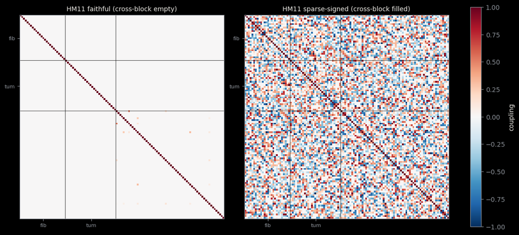

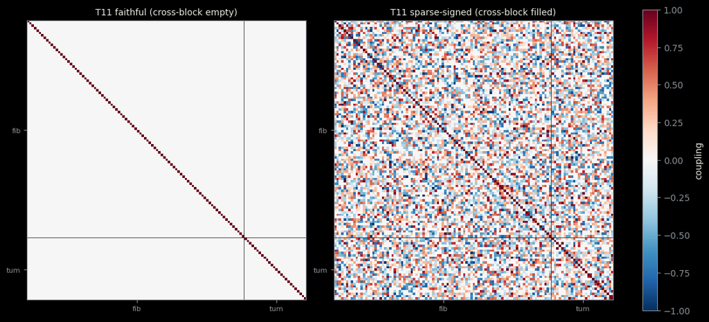

```
saved G2G heatmaps
```

```python
def block_heatmap(ax, G, fib_idx, tum_idx, title):
    other=[i for i in range(len(G)) if i not in fib_idx and i not in tum_idx]
    order=fib_idx+tum_idx+other; M=G[np.ix_(order,order)]
    nz=M[np.abs(M)>1e-9]; lim=np.percentile(np.abs(nz),99) if nz.size else 1.0
    im=ax.imshow(M, cmap="RdBu_r", norm=TwoSlopeNorm(0,-lim,lim))
    nf,nt=len(fib_idx),len(tum_idx)
    for b in (nf,nf+nt): ax.axhline(b-0.5,color="k",lw=0.5); ax.axvline(b-0.5,color="k",lw=0.5)
    ax.set_title(title,fontsize=10); ax.set_xticks([nf/2,nf+nt/2]); ax.set_xticklabels(["fib","tum"],fontsize=8)
    ax.set_yticks([nf/2,nf+nt/2]); ax.set_yticklabels(["fib","tum"],fontsize=8); return im
for nm, d in data.items():
    fig,ax=plt.subplots(1,2,figsize=(11,5),constrained_layout=True)
    block_heatmap(ax[0], d["G2G_faithful"], d["fib_genes"], d["tum_genes"], f"{nm} faithful (cross-block empty)")
    im=block_heatmap(ax[1], d["G2G_sparse"], d["fib_genes"], d["tum_genes"], f"{nm} sparse-signed (cross-block filled)")
    fig.colorbar(im,ax=ax,fraction=0.04,label="coupling"); fig.savefig(f"{OUTDIR}/{nm}_G2G_heatmap.png",dpi=130,bbox_inches="tight"); plt.show()
print("saved G2G heatmaps")
```

### 2.2 Coupling-variant response comparison

The same initial programme downscaling is evaluated under the faithful, signed, and sparse signed coupling variants. This comparison describes how the fitted model response changes when signed off-diagonal relationships are permitted and retained. It is an internal model comparison rather than experimental validation of the cross block.

```python
def strongest_fibrotic(d, model):
    drv,cc,g2i=d["drv"],d["cc"],d["g2i"]
    fib=[c for c in drv[drv.role=="perturb_target"].CC.unique() if str(drv[drv.CC==c].theme.iloc[0]) in FIBROTIC_THEMES]
    best,bestd,pack=None,-1e9,None; base=relax(model,d["expr"],d["edges"],d["n"])
    for c in fib:
        src=np.where(cc==c)[0]; sub=drv[(drv.CC==c)&(drv.role=="perturb_target")].head(TOP)
        gidx=[g2i[g] for g in sub.gene if g in g2i]
        if not gidx or len(src)==0: continue
        cf=relax(model,initial_downscale(d["expr"],gidx,src),d["edges"],d["n"])
        dd=-float((cf-base)[d["tum_spots"]][:,d["tum_genes"]].mean())
        if dd>bestd: best,bestd,pack=c,dd,(src,sub,gidx)
    return best,pack,base

nm0="HM11"; d0=data[nm0]
print(f"propagation test on {nm0} (faithful vs signed vs sparse):")
faithful0=train_mode(get_loader(d0["tmp"]), d0["n"], "faithful")
signed0  =train_mode(get_loader(d0["tmp"]), d0["n"], "signed")
models3={"faithful":faithful0,"signed":signed0,"sparse":sparse_models[nm0]}
best,pack,_=strongest_fibrotic(d0, sparse_models[nm0]); src,sub,gidx=pack
rng=np.random.RandomState(SEED); null_rows=[]
for mode,mdl in models3.items():
    base=relax(mdl,d0["expr"],d0["edges"],d0["n"])
    cf=relax(mdl,initial_downscale(d0["expr"],gidx,src),d0["edges"],d0["n"])
    drv_eff=float((cf-base)[d0["tum_spots"]][:,d0["tum_genes"]].mean())
    rnd=rng.choice(d0["n"],size=len(gidx),replace=False).tolist()
    cfr=relax(mdl,initial_downscale(d0["expr"],rnd,src),d0["edges"],d0["n"])
    rnd_eff=float((cfr-base)[d0["tum_spots"]][:,d0["tum_genes"]].mean())
    null_rows.append({"mode":mode,"driver_tumour_delta":round(drv_eff,6),"random_tumour_delta":round(rnd_eff,6)})
    print(f"  {mode:8s} driverΔ={drv_eff:+.6f}  randomΔ={rnd_eff:+.6f}  "
          f"({'~null' if abs(drv_eff)<5e-5 else 'effect present'})")
pd.DataFrame(null_rows).to_csv(f"{OUTDIR}/propagation_null.csv", index=False)
print("saved propagation_null.csv")
```

```
propagation test on HM11 (faithful vs signed vs sparse):
```

```
  faithful driverΔ=+0.000007  randomΔ=+0.000015  (~null)
  signed   driverΔ=-0.000708  randomΔ=-0.000141  (effect present)
  sparse   driverΔ=-0.000878  randomΔ=-0.000479  (effect present)
saved propagation_null.csv
```

### 2.3 Mechanical and spatial checks

Three internal checks are reported. The first measures the spherical transformation round trip. The second verifies that the selected source programme is strongly reduced after initial downscaling and relaxation. The third measures the response as a function of graph distance from the source. The distance check is descriptive: locality is supported only if the response declines beyond the immediate source neighbourhood.

```python
d0=data["HM11"]; mdl=sparse_models["HM11"]; expr=d0["expr"]; edges=d0["edges"]; n=d0["n"]
scm=simcomen(input_dim=n,output_dim=n,n_neighbors=K,seed=SEED); scm.to(device)
sx=torch.nan_to_num(scm.calc_sphex(torch.from_numpy(expr).to(device))); gx=scm.calc_gex(sx).detach().cpu().numpy()
rt=np.corrcoef(expr.ravel(),gx.ravel())[0,1]
print(f"[V1] round-trip corr = {rt:.4f} ({'faithful' if rt>0.99 else 'lossy'})")
best,pack,base=strongest_fibrotic(d0,mdl); src,sub,gidx=pack
cf=relax(mdl,initial_downscale(expr,gidx,src),edges,n)
b,a_=base[np.ix_(src,gidx)].mean(),cf[np.ix_(src,gidx)].mean()
print(f"[V2] KO gene at source: {b:.4f} -> {a_:.4f} ({'registers' if a_<b*0.8 else 'did NOT take'})")
g=kneighbors_graph(d0["a"].obsm["spatial"],K,include_self=False); adj=((g+g.T)>0).astype(np.int8).tocsr()
dist=shortest_path(adj,method="D",unweighted=True,indices=src).min(0)
nonko=[i for i in range(n) if i not in gidx]; eff=np.abs(cf[:,nonko]-base[:,nonko]).mean(1)
print("[V3] effect vs hop distance:")
for hop in range(4):
    m=dist==hop
    if m.sum(): print(f"     hop {hop}: n={int(m.sum()):4d} mean_effect={eff[m].mean():.6f}")
print("     (large at source, collapses by hop 1 at the gene level)")


# [V4] SIGNED SIGN-RECOVERY (the validation the signed extension actually needs)
# Plant a SIGNED symmetric ground-truth coupling, GENERATE spatial expression with
# SCE (Simcomen), then INFER it back with the signed CCE (Celcomen) and check that
# the SIGN of the couplings round-trips. This is the signed analogue of the paper's
# Fig-1c self-consistency test and direcly answers "is the signed matrix right?".

import anndata as ad
from celcomen.utils.helpers import get_pos
from scipy.stats import spearmanr

def signed_sign_recovery(n_genes=6, n_x=14, n_y=14, gen_steps=250, seed=SEED):
    try:
        rng = np.random.RandomState(seed)
        Wt = rng.uniform(-1, 1, (n_genes, n_genes)).astype("float32")
        Wt = normalize_g2g_signed((Wt + Wt.T) / 2)                 # signed symmetric ground truth
        Gi = np.eye(n_genes, dtype="float32")
        coords = get_pos(n_x, n_y); e = edges_of(coords)
        # ---- generate with SCE (Simcomen) carrying the planted signed coupling ----
        scm = simcomen(input_dim=n_genes, output_dim=n_genes, n_neighbors=K, seed=seed)
        scm.set_g2g(torch.from_numpy(Wt.copy())); scm.set_g2g_intra(torch.from_numpy(Gi.copy())); scm.to(device)
        sph0 = torch.from_numpy(rng.uniform(0, np.pi, (coords.shape[0], n_genes - 1)).astype("float32"))
        scm.set_sphex(sph0.to(device))
        opt = torch.optim.SGD(scm.parameters(), lr=1e-2, momentum=0)
        for _ in range(gen_steps):
            msg, mi, lz = scm(e.to(device), 1)
            loss = -(-lz + ZMFT*torch.trace(torch.mm(msg, scm.gex.t())) + ZMFT*torch.trace(torch.mm(mi, scm.gex.t())))
            loss.backward(); opt.step(); opt.zero_grad()
        gen = np.nan_to_num(scm.gex.detach().cpu().numpy())
        nf = np.sqrt((gen**2).sum(1, keepdims=True)); nf[nf == 0] = 1; gen = (gen/nf).astype("float32")
        # ---- infer back with signed CCE (reuse the exact working training path) ----
        A = ad.AnnData(X=csr_matrix(gen)); A.obs[SAMPLE_ID] = "0"
        A.var_names = [f"g{i}" for i in range(n_genes)]; A.obsm["spatial"] = coords
        tmp = tempfile.NamedTemporaryFile(suffix=".h5ad", delete=False).name; A.write(tmp); _TMP.append(tmp)
        mdl = train_mode(get_loader(tmp), n_genes, "signed")
        Wr = mdl.conv1.lin.weight.detach().cpu().numpy(); Wr = (Wr + Wr.T)/2
        iu = np.triu_indices(n_genes, k=1)
        wt, wr = Wt[iu], Wr[iu]
        sign_agree = float((np.sign(wt) == np.sign(wr)).mean())
        rho = float(spearmanr(wt, wr).correlation)
        neg = wt < 0
        neg_agree = float((np.sign(wt[neg]) == np.sign(wr[neg])).mean()) if neg.any() else np.nan
        return dict(sign_agreement=sign_agree, negative_sign_agreement=neg_agree, spearman=rho, n_neg=int(neg.sum()))
    except Exception as ex:
        return dict(error=str(ex))

_sr = signed_sign_recovery()
if "error" in _sr:
    print(f"[V4] signed round-trip skipped: {_sr['error']}")
else:
    print(f"[V4] signed round-trip: sign-agreement={_sr['sign_agreement']:.2f} "
          f"(negatives {_sr['negative_sign_agreement']:.2f} over {_sr['n_neg']} antagonistic pairs) "
          f"| Spearman rho={_sr['spearman']:+.2f}  "
          f"({'signs recovered' if _sr['sign_agreement']>0.7 else 'weak sign recovery'})")
    pd.DataFrame([_sr]).to_csv(f"{OUTDIR}/signed_sign_recovery.csv", index=False)
```

```
[V1] round-trip corr = 0.9985 (faithful)
[V2] KO gene at source: 0.1262 -> 0.0144 (registers)
[V3] effect vs hop distance:
     hop 0: n= 587 mean_effect=0.003925
     hop 1: n=1061 mean_effect=0.001911
     hop 2: n= 728 mean_effect=0.001948
     hop 3: n= 451 mean_effect=0.001959
     (large at source, collapses by hop 1 at the gene level)
```

```
[V4] signed round-trip: sign-agreement=0.93 (negatives 0.75 over 4 antagonistic pairs) | Spearman rho=+0.48  (signs recovered)
```

### 2.4 Fibrotic-niche programme ranking

Each fibrotic niche is evaluated in turn using initial programme downscaling followed by relaxation. Niches are ranked by the decrease in the tumour-programme readout. The leading niche from the executed seed is carried forward to the dose, leave-one-out, and spatial analyses. Because the ranking changes under some seeds, it is interpreted as a seed-specific model-response ranking.

```python
baseline_rows, strongest = [], {}
for nm, st in states.items():
    drv,cc,g2i=st["drv"],st["cc"],st["g2i"]
    fib=[c for c in drv[drv.role=="perturb_target"].CC.unique() if str(drv[drv.CC==c].theme.iloc[0]) in FIBROTIC_THEMES]
    print(f"\n--- {nm} niche knockout scan ---")
    rows=[]; best=None; bestd=-1e9; pack=None; cf_best=None; resp={}
    for c in fib:
        src=np.where(cc==c)[0]; sub=drv[(drv.CC==c)&(drv.role=="perturb_target")].head(TOP)
        gidx=[g2i[g] for g in sub.gene if g in g2i]
        if not gidx or len(src)==0: continue
        cf=relax(st["model"],initial_downscale(st["expr"],gidx,src),st["edges"],st["n"])
        dvec=(cf-st["base"])[st["tum_spots"]].mean(0)
        d=float(dvec[st["tum_genes"]].mean()); down=float((dvec[st["tum_genes"]]<0).mean())
        resp[c]=pd.Series(dvec[st["tum_genes"]], index=[st["gene_names"][i] for i in st["tum_genes"]])
        rows.append({"section":nm,"niche":c,"n_spots":len(src),"drivers":",".join(sub.gene),
                     "tumour_delta":round(d,6),"tumour_down_frac":round(down,2)})
        if best is None or -d>bestd: best,bestd,pack,cf_best=c,-d,(src,sub,gidx),cf
        print(f"  {c:5s} tumourΔ={d:+.6f} down={down:.2f} drivers={','.join(sub.gene)}")
    strongest[nm]=(best,pack,cf_best,pd.DataFrame(resp).T if resp else None)
    df=pd.DataFrame(rows).sort_values("tumour_delta"); baseline_rows.append(df)
    print(f"  >> strongest fibrotic niche: {best}")
baseline_df=pd.concat(baseline_rows, ignore_index=True); baseline_df.to_csv(f"{OUTDIR}/niche_programme_downscaling.csv", index=False)
print("\nsaved niche_programme_downscaling.csv")
```

[output not shown]

### 2.5 Control battery

The selected programme response is compared with size-matched random genes, alternative source niches, a shuffled graph, and shuffled source labels. Each control addresses a different question and is audited separately. A control is interpreted only when its construction provides a suitable comparison; the random-niche audit later identifies limitations in that control family.

```python
def nonfibrotic_niches(st):
    drv=st["drv"]
    return [c for c in drv[drv.role=="perturb_target"].CC.unique() if str(drv[drv.CC==c].theme.iloc[0]) not in FIBROTIC_THEMES]

def control_battery(st, best, pack, n_random=N_RANDOM):
    src_rows, sub, gidx = pack
    n,expr,edges = st["n"],st["expr"],st["edges"]; tum,tum_genes,base=st["tum_spots"],st["tum_genes"],st["base"]; cc=st["cc"]
    rng=np.random.RandomState(SEED); out={}
    cf=relax(st["model"],initial_downscale(expr,gidx,src_rows),edges,n); out["selected_programme"]=float((cf-base)[tum][:,tum_genes].mean())
    rg=[]
    for _ in range(n_random):
        rnd=rng.choice(n,size=len(gidx),replace=False).tolist()
        cf_r=relax(st["model"],initial_downscale(expr,rnd,src_rows),edges,n); rg.append(float((cf_r-base)[tum][:,tum_genes].mean()))
    out["random_gene_mean"]=float(np.mean(rg)); out["random_gene_sd"]=float(np.std(rg))
    # random non-fibrotic niche, averaged over up to 3 draws (robust, not a single draw)
    nf=nonfibrotic_niches(st); rn=[]
    if nf:
        for rc in rng.choice(nf, size=min(3,len(nf)), replace=False):
            rsrc=np.where(cc==rc)[0]; rsub=st["drv"][(st["drv"].CC==rc)&(st["drv"].role=="perturb_target")].head(TOP)
            rgidx=[st["g2i"][g] for g in rsub.gene if g in st["g2i"]]
            if rgidx and len(rsrc):
                cf_n=relax(st["model"],initial_downscale(expr,rgidx,rsrc),edges,n); rn.append(float((cf_n-base)[tum][:,tum_genes].mean()))
    out["random_niche_mean"]=float(np.mean(rn)) if rn else np.nan
    # shuffled spatial graph (retrain on shuffled coords)
    rsh=np.random.RandomState(1000+SEED); coords=st["a"].obsm["spatial"].copy(); rsh.shuffle(coords)
    edges_sh=edges_of(coords); a_sh=st["a"].copy(); a_sh.obsm["spatial"]=coords
    tmp_sh=tempfile.NamedTemporaryFile(suffix=".h5ad",delete=False).name; a_sh.write(tmp_sh)
    model_sh=train_sparse(get_loader(tmp_sh), n); os.unlink(tmp_sh)
    base_sh=relax(model_sh,expr,edges_sh,n); cf_sh=relax(model_sh,initial_downscale(expr,gidx,src_rows),edges_sh,n)
    out["shuffled_graph"]=float((cf_sh-base_sh)[tum][:,tum_genes].mean())
    # shuffled labels (random source spots, same count)
    rr=np.random.RandomState(2000+SEED).choice(st["a"].n_obs,size=max(1,len(src_rows)),replace=False)
    cf_sl=relax(st["model"],initial_downscale(expr,gidx,rr),edges,n); out["shuffled_labels"]=float((cf_sl-base)[tum][:,tum_genes].mean())
    out["specificity"]=abs(out["selected_programme"])/(abs(out["random_gene_mean"])+1e-12)
    return out

ctrl_rows=[]
for nm, st in states.items():
    best,pack,_,_=strongest[nm]
    if pack is None: continue
    print(f"\n--- {nm} control battery (niche {best}) ---")
    cb=control_battery(st,best,pack)
    for k in ["selected_programme","random_gene_mean","random_niche_mean","shuffled_graph","shuffled_labels"]:
        print(f"  {k:18s} = {cb[k]:+.6f}" if np.isfinite(cb[k]) else f"  {k:18s} = NA")
    print(f"  nominal specificity (selected/random) = {cb['specificity']:.2f} ('descriptive ratio')")
    cb["section"]=nm; cb["niche"]=best; ctrl_rows.append(cb)
pd.DataFrame(ctrl_rows).to_csv(f"{OUTDIR}/controls.csv", index=False); print("\nsaved controls.csv")
```

```
--- HM11 control battery (niche CC4) ---
```

[output not shown]

[output not shown]

### 2.6 Dose response

The selected fibrotic programme is scaled from strong reduction to model-scale overexpression. The analysis tests whether the tumour-programme readout changes smoothly around the unperturbed input. A monotonic sign reversal supports a consistent fitted-model response, but it does not identify a biological causal effect.

```python
dose_rows=[]
for nm, st in states.items():
    best,pack,_,_=strongest[nm]
    if pack is None: continue
    src,sub,gidx=pack
    for f in DOSES:
        cf=relax(st["model"],dose_perturb(st["expr"],gidx,src,f),st["edges"],st["n"])
        d=float((cf-st["base"])[st["tum_spots"]][:,st["tum_genes"]].mean())
        tag="KO" if f==0 else ("baseline" if f==1 else ("overexpr" if f>1 else "knockdown"))
        dose_rows.append({"section":nm,"niche":best,"dose":f,"tumour_delta":round(d,6),"kind":tag})
        print(f"  {nm} dose={f:.2f} ({tag:9s}) tumourΔ={d:+.6f}")
dose_df=pd.DataFrame(dose_rows); dose_df.to_csv(f"{OUTDIR}/dose_response.csv", index=False); print("saved dose_response.csv")
```

```
  HM11 dose=0.00 (KO       ) tumourΔ=-0.000878
  HM11 dose=0.25 (knockdown) tumourΔ=-0.000638
  HM11 dose=0.50 (knockdown) tumourΔ=-0.000410
  HM11 dose=0.75 (knockdown) tumourΔ=-0.000197
  HM11 dose=1.00 (baseline ) tumourΔ=-0.000001
  HM11 dose=1.50 (overexpr ) tumourΔ=+0.000336
  HM11 dose=2.00 (overexpr ) tumourΔ=+0.000604
  T11 dose=0.00 (KO       ) tumourΔ=-0.001675
  T11 dose=0.25 (knockdown) tumourΔ=-0.001156
  T11 dose=0.50 (knockdown) tumourΔ=-0.000703
  T11 dose=0.75 (knockdown) tumourΔ=-0.000319
  T11 dose=1.00 (baseline ) tumourΔ=+0.000001
  T11 dose=1.50 (overexpr ) tumourΔ=+0.000466
  T11 dose=2.00 (overexpr ) tumourΔ=+0.000747
saved dose_response.csv
```

### 2.7 Leave-one-driver-out attribution

Each driver is omitted from the selected multi-gene programme in turn, and the resulting change in the programme-level response is measured. These values are conditional model-attribution scores within a multi-gene perturbation and are not isolated gene-specific causal effect sizes.

```python
loo_rows=[]
for nm, st in states.items():
    best,pack,_,_=strongest[nm]
    if pack is None: continue
    src,sub,gidx=pack
    cf_full=relax(st["model"],initial_downscale(st["expr"],gidx,src),st["edges"],st["n"])
    full=-float((cf_full-st["base"])[st["tum_spots"]][:,st["tum_genes"]].mean())
    print(f"\n--- {nm} {best}: full decrease score={full:+.6f} ---")
    for j,gname in enumerate(sub.gene):
        keep=[g for i,g in enumerate(gidx) if i!=j]
        cf=relax(st["model"],initial_downscale(st["expr"],keep,src),st["edges"],st["n"])
        supp=-float((cf-st["base"])[st["tum_spots"]][:,st["tum_genes"]].mean())
        loo_rows.append({"section":nm,"niche":best,"gene":gname,"decrease_score_without_gene":round(supp,6),"contribution":round(full-supp,6)})
        print(f"  leave out {gname:8s} -> contribution={full-supp:+.6f}")
loo_df=pd.DataFrame(loo_rows).sort_values(["section","contribution"],ascending=[True,False]); loo_df.to_csv(f"{OUTDIR}/leave_one_out.csv", index=False)
print("\nsaved leave_one_out.csv")
```

```
--- HM11 CC4: full decrease_score=+0.000878 ---
  leave out VIM      -> contribution=+0.000023
  leave out TIMP1    -> contribution=+0.000313
  leave out IGFBP7   -> contribution=+0.000197
  leave out CCN2     -> contribution=+0.000206
  leave out DCN      -> contribution=+0.000178

--- T11 CC5: full decrease_score=+0.001675 ---
  leave out COL3A1   -> contribution=+0.000393
  leave out COL1A2   -> contribution=+0.000415
  leave out DCN      -> contribution=+0.000345
  leave out COL1A1   -> contribution=+0.000385
  leave out CCN2     -> contribution=+0.000243

saved leave_one_out.csv
```

### 2.8 Descriptive comparison between primary tumour and metastasis

A shared fibrotic driver set is evaluated in HM11 and T11, and the tumour-gene responses are compared. The matched sections provide a descriptive within-patient contrast. Because there is only one primary and one metastatic section, the differences are not generalised as primary-versus-metastatic effects.

```python
def fib_rows(st):
    drv,cc=st["drv"],st["cc"]
    fib=[c for c in drv[drv.role=="perturb_target"].CC.unique() if str(drv[drv.CC==c].theme.iloc[0]) in FIBROTIC_THEMES]
    return np.where(np.isin(cc,fib))[0]
per_gene={}
for nm, st in states.items():
    gidx=[st["g2i"][g] for g in SHARED_DRIVERS if g in st["g2i"]]; rows=fib_rows(st)
    cf=relax(st["model"],initial_downscale(st["expr"],gidx,rows),st["edges"],st["n"])
    per_gene[nm]=pd.Series((cf-st["base"])[st["tum_spots"]].mean(0), index=st["gene_names"])
    print(f"  {nm}: initially downscaled {[g for g in SHARED_DRIVERS if g in st['g2i']]} in {len(rows)} fibrotic spots")
tg=sorted(set(st["gene_names"][i] for st in states.values() for i in st["tum_genes"]))
diff_df=pd.DataFrame([{"gene":g,"T11_primary_delta":round(float(per_gene["T11"].get(g,np.nan)),6),
                       "HM11_met_delta":round(float(per_gene["HM11"].get(g,np.nan)),6),
                       "difference_met_minus_primary":round(float(per_gene["HM11"].get(g,np.nan)-per_gene["T11"].get(g,np.nan)),6)} for g in tg]
                     ).sort_values("difference_met_minus_primary")
diff_df.to_csv(f"{OUTDIR}/differential_response.csv", index=False)
print("\n(pooled fibrotic-programme downscaling; coarser than per-niche) top differential genes:")
print(diff_df.head(3).to_string(index=False)); print(diff_df.tail(3).to_string(index=False))
```

[output not shown]

### 2.9 Reciprocal model-response asymmetry

The analysis compares the tumour-programme response after reducing fibrotic drivers with the fibrotic-programme response after reducing tumour drivers. The two experiments use different driver sets, different source-spot populations, and a symmetric fitted coupling. Their ratio is therefore reported as model-response asymmetry, not as evidence that either compartment is causally upstream.

```python
def drivers_of(st, themes):
    drv,g2i=st["drv"],st["g2i"]; sel=drv[(drv.role=="perturb_target")&(drv.theme.isin(themes))]; genes=[]
    for c in sel.CC.unique(): genes+=list(drv[(drv.CC==c)&(drv.role=="perturb_target")].head(TOP).gene)
    return [g2i[g] for g in dict.fromkeys(genes) if g in g2i]
bidir_rows=[]
for nm, st in states.items():
    fd=drivers_of(st,list(FIBROTIC_THEMES)); td=drivers_of(st,list(TUMOUR_THEMES))
    nf=int(st["fib_spots"].sum()); nt=int(st["tum_spots"].sum())
    cf_f=relax(st["model"],initial_downscale(st["expr"],fd,np.where(st["fib_spots"])[0]),st["edges"],st["n"])
    fwd=float((cf_f-st["base"])[st["tum_spots"]][:,st["tum_genes"]].mean())
    cf_r=relax(st["model"],initial_downscale(st["expr"],td,np.where(st["tum_spots"])[0]),st["edges"],st["n"])
    rev=float((cf_r-st["base"])[st["fib_spots"]][:,st["fib_genes"]].mean())
    raw=abs(fwd)/(abs(rev)+1e-12); norm=(abs(fwd)/max(len(fd),1))/((abs(rev)/max(len(td),1))+1e-12)
    who="larger fibrotic-to-tumour response" if raw>1.3 else ("larger tumour-to-fibrotic response" if raw<0.77 else "similar response magnitude")
    bidir_rows.append({"section":nm,"stroma_to_tumour":round(fwd,6),"tumour_to_stroma":round(rev,6),
                       "raw_asymmetry":round(raw,2),"norm_per_driver":round(norm,2),"n_fib_spots":nf,"n_tum_spots":nt,"response_asymmetry_label":who})
    print(f"  {nm}: stroma→tumour={fwd:+.6f} tumour→stroma={rev:+.6f} | raw={raw:.1f} per-driver={norm:.1f} (sizes fib={nf} tum={nt}) -> {who}")
pd.DataFrame(bidir_rows).to_csv(f"{OUTDIR}/bidirectional.csv", index=False)
print("saved bidirectional.csv  (interpret as model-response asymmetry, not causal direction)")
```

[output not shown]

### 2.10 Spatial dose response

The dose response is summarised by graph distance from the selected source niche. A stronger slope near the source than in distant tumour spots would support a localised model response. Similar slopes across distance groups instead support a global or mean-field interpretation.

```python
sp_rows=[]
for nm, st in states.items():
    best,pack,_,_=strongest[nm]
    if pack is None: continue
    src,sub,gidx=pack
    g=kneighbors_graph(st["a"].obsm["spatial"],K,include_self=False); adj=((g+g.T)>0).astype(np.int8).tocsr()
    dist=shortest_path(adj,method="D",unweighted=True,indices=src).min(0)
    near=st["tum_spots"]&(dist<=2); deep=st["tum_spots"]&(dist>=4)
    for f in DOSES:
        cf=relax(st["model"],dose_perturb(st["expr"],gidx,src,f),st["edges"],st["n"]); dd=cf-st["base"]
        dn=float(dd[near][:,st["tum_genes"]].mean()) if near.sum() else np.nan
        dp=float(dd[deep][:,st["tum_genes"]].mean()) if deep.sum() else np.nan
        sp_rows.append({"section":nm,"niche":best,"dose":f,"interface_delta":round(dn,6),"deep_delta":round(dp,6)})
    sdf=pd.DataFrame([r for r in sp_rows if r["section"]==nm and r["dose"]<=1.0])
    sn=np.polyfit(sdf.dose,sdf.interface_delta,1)[0]; sd=np.polyfit(sdf.dose,sdf.deep_delta,1)[0]
    print(f"  {nm} ({best}): interface n={int(near.sum())} deep n={int(deep.sum())} | slope interface={sn:+.5f} deep={sd:+.5f} "
          f"({'interface more sensitive' if abs(sn)>abs(sd)*1.2 else 'similar'})")
pd.DataFrame(sp_rows).to_csv(f"{OUTDIR}/spatial_dose.csv", index=False); print("saved spatial_dose.csv")
```

```
  HM11 (CC4): interface n=316 deep n=268 | slope interface=+0.00085 deep=+0.00090 (similar)
  T11 (CC5): interface n=43 deep n=127 | slope interface=+0.00169 deep=+0.00167 (similar)
saved spatial_dose.csv
```

### 2.11 Sensitivity across seeds

The coupling is retrained under seeds 0, 1, and 2, and the leading niche, response magnitude, random-gene specificity, and dose-response sign reversal are recomputed. This analysis distinguishes features that retain their sign from rankings and pair-level details that remain seed-sensitive.

[output not shown]

[output not shown]

[output not shown]

[output not shown]

[output not shown]

[output not shown]

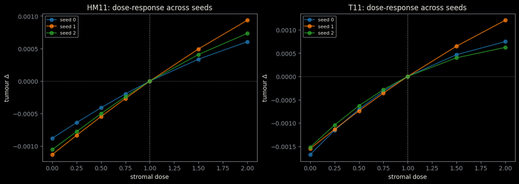

```
saved robustness_per_seed.csv, robustness_summary.csv, robustness_dose_curves.png
```

```python
rob_per_seed=[]; rob_dose={}
for seed in SEEDS:
    for nm, d in data.items():
        model = train_for_seed(get_loader(d["tmp"]), d["n"], seed)
        base = relax(model, d["expr"], d["edges"], d["n"])
        drv,cc,g2i=d["drv"],d["cc"],d["g2i"]
        fib=[c for c in drv[drv.role=="perturb_target"].CC.unique() if str(drv[drv.CC==c].theme.iloc[0]) in FIBROTIC_THEMES]
        best=None; bestd=-1e9; bestpack=None
        for c in fib:
            src=np.where(cc==c)[0]; sub=drv[(drv.CC==c)&(drv.role=="perturb_target")].head(TOP)
            gidx=[g2i[g] for g in sub.gene if g in g2i]
            if not gidx or len(src)==0: continue
            cf=relax(model,initial_downscale(d["expr"],gidx,src),d["edges"],d["n"])
            dd=-float((cf-base)[d["tum_spots"]][:,d["tum_genes"]].mean())
            if dd>bestd: best,bestd,bestpack=c,dd,(src,gidx)
        src,gidx=bestpack
        rng=np.random.RandomState(seed); rg=[]
        for _ in range(3):
            rnd=rng.choice(d["n"],size=len(gidx),replace=False).tolist()
            cfr=relax(model,initial_downscale(d["expr"],rnd,src),d["edges"],d["n"]); rg.append(-float((cfr-base)[d["tum_spots"]][:,d["tum_genes"]].mean()))
        spec=abs(bestd)/(abs(np.mean(rg))+1e-12)
        dvals=[]
        for f in DOSES:
            cf=relax(model,dose_perturb(d["expr"],gidx,src,f),d["edges"],d["n"])
            dvals.append(float((cf-base)[d["tum_spots"]][:,d["tum_genes"]].mean()))
        rob_dose[(seed,nm)]=dvals; signflip=bool(np.sign(dvals[0])*np.sign(dvals[-1])<0)
        rob_per_seed.append({"seed":seed,"section":nm,"top_niche":best,"decrease_score":round(bestd,6),
                             "specificity":round(spec,2),"dose_sign_flip":signflip})
        print(f"  seed {seed} {nm}: top={best} suppression={bestd:+.6f} spec={spec:.2f} signflip={signflip}")
rob_df=pd.DataFrame(rob_per_seed); rob_df.to_csv(f"{OUTDIR}/robustness_per_seed.csv", index=False)
rob_summary={}
for nm in data:
    sub=rob_df[rob_df.section==nm]; tc=sub.top_niche.value_counts()
    rob_summary[nm]=dict(top_niche_mode=tc.index[0], top_niche_consistent=bool(tc.iloc[0]==len(sub)),
                         decrease_score_mean=float(sub.decrease_score.mean()), decrease_score_sd=float(sub.decrease_score.std()),
                         specificity_mean=float(sub.specificity.mean()), signflip_all=bool(sub.dose_sign_flip.all()))
    s=rob_summary[nm]
    print(f"\n{nm}: top niche {'CONSISTENT' if s['top_niche_consistent'] else 'VARIES'} ({s['top_niche_mode']}); "
          f"decrease_score={s['decrease_score_mean']:+.6f}±{s['decrease_score_sd']:.6f}; nominal_spec={s['specificity_mean']:.2f}; "
          f"dose sign-flip all seeds={s['signflip_all']}")
pd.DataFrame(rob_summary).T.to_csv(f"{OUTDIR}/robustness_summary.csv")
fig,ax=plt.subplots(1,len(data),figsize=(6*len(data),4.2),squeeze=False,constrained_layout=True)
for j,nm in enumerate(data):
    for seed in SEEDS: ax[0][j].plot(DOSES, rob_dose[(seed,nm)], "o-", alpha=0.75, label=f"seed {seed}")
    ax[0][j].axhline(0,color="grey",lw=0.7,ls=":"); ax[0][j].axvline(1,color="grey",lw=0.7,ls="--")
    ax[0][j].set_title(f"{nm}: dose-response across seeds"); ax[0][j].set_xlabel("stromal dose"); ax[0][j].set_ylabel("tumour Δ"); ax[0][j].legend(fontsize=8)
fig.savefig(f"{OUTDIR}/robustness_dose_curves.png",dpi=130,bbox_inches="tight"); plt.show()
print("\nsaved robustness_per_seed.csv, robustness_summary.csv, robustness_dose_curves.png")
```

### 2.12 Combined-niche non-additivity

Pairs of leading fibrotic niches are evaluated together and compared with the sum of their separate programme-response scores. The difference between the combined and additive values is reported as operational non-additivity under the defined combined perturbation. It is an exploratory fitted-model summary and is not presented as validated biological cooperation.

```
  seed0 HM11 CC4+CC8: obs=+0.00235 exp=+0.00145 syn=+0.00090 -> positive non-additivity
  seed0 HM11 CC4+CC6: obs=+0.00174 exp=+0.00101 syn=+0.00073 -> positive non-additivity
  seed0 HM11 CC8+CC6: obs=+0.00132 exp=+0.00070 syn=+0.00062 -> positive non-additivity
```

```
  seed0 T11 CC5+CC8: obs=+0.00596 exp=+0.00268 syn=+0.00328 -> positive non-additivity
  seed0 T11 CC5+CC11: obs=+0.00536 exp=+0.00225 syn=+0.00311 -> positive non-additivity
  seed0 T11 CC8+CC11: obs=+0.00361 exp=+0.00158 syn=+0.00203 -> positive non-additivity
```

```
  seed1 HM11 CC8+CC4: obs=+0.00361 exp=+0.00210 syn=+0.00151 -> positive non-additivity
  seed1 HM11 CC8+CC11: obs=+0.00137 exp=+0.00129 syn=+0.00008 -> additive
  seed1 HM11 CC4+CC11: obs=+0.00195 exp=+0.00113 syn=+0.00081 -> positive non-additivity
```

```
  seed1 T11 CC8+CC5: obs=+0.00549 exp=+0.00266 syn=+0.00283 -> positive non-additivity
  seed1 T11 CC8+CC11: obs=+0.00487 exp=+0.00229 syn=+0.00258 -> positive non-additivity
  seed1 T11 CC5+CC11: obs=+0.00429 exp=+0.00185 syn=+0.00244 -> positive non-additivity
```

```
  seed2 HM11 CC4+CC8: obs=+0.00328 exp=+0.00189 syn=+0.00139 -> positive non-additivity
  seed2 HM11 CC4+CC6: obs=+0.00172 exp=+0.00124 syn=+0.00048 -> positive non-additivity
  seed2 HM11 CC8+CC6: obs=+0.00190 exp=+0.00102 syn=+0.00088 -> positive non-additivity
```

```
  seed2 T11 CC5+CC8: obs=+0.00605 exp=+0.00275 syn=+0.00330 -> positive non-additivity
  seed2 T11 CC5+CC4: obs=+0.00236 exp=+0.00162 syn=+0.00074 -> positive non-additivity
  seed2 T11 CC8+CC4: obs=+0.00268 exp=+0.00134 syn=+0.00134 -> positive non-additivity

combined-niche non-additivity summary across seeds:
section niche_A niche_B  mean_nonadditivity  sd_nonadditivity  mean_observed  mean_expected  label_mode
   HM11     CC4    CC11      0.000814         NaN       0.001948       0.001134 positive non-additivity
   HM11     CC4     CC6      0.000605    0.000176       0.001730       0.001124 positive non-additivity
   HM11     CC4     CC8      0.001146    0.000350       0.002816       0.001670 positive non-additivity
   HM11     CC8    CC11      0.000078         NaN       0.001372       0.001294    additive
   HM11     CC8     CC4      0.001508         NaN       0.003607       0.002100 positive non-additivity
   HM11     CC8     CC6      0.000750    0.000185       0.001612       0.000863 positive non-additivity
    T11     CC5    CC11      0.002774    0.000470       0.004826       0.002052 positive non-additivity
    T11     CC5     CC4      0.000736         NaN       0.002360       0.001624 positive non-additivity
    T11     CC5     CC8      0.003288    0.000016       0.006004       0.002716 positive non-additivity
    T11     CC8    CC11      0.002306    0.000392       0.004241       0.001936 positive non-additivity
    T11     CC8     CC4      0.001341         NaN       0.002679       0.001339 positive non-additivity
    T11     CC8     CC5      0.002826         NaN       0.005487       0.002660 positive non-additivity
```

[figure not shown]

```
saved combined-niche non-additivity outputs
```

```python
def _decrease_score(model, expr, edges, n, base, tum_mask, tum_idx, gidx, rows):
    cf = relax(model, initial_downscale(expr, gidx, rows), edges, n)
    return -float((cf - base)[tum_mask][:, tum_idx].mean())   # positive = tumour-programme decrease score

syn_rows=[]
for seed in SEEDS:
    for nm, d in data.items():
        model = train_for_seed(get_loader(d["tmp"]), d["n"], seed)
        base = relax(model, d["expr"], d["edges"], d["n"])
        drv,cc,g2i = d["drv"], d["cc"], d["g2i"]
        tum_mask, tum_idx = d["tum_spots"], d["tum_genes"]
        fib=[c for c in drv[drv.role=="perturb_target"].CC.unique()
             if str(drv[drv.CC==c].theme.iloc[0]) in FIBROTIC_THEMES]
        single={}
        for c in fib:
            rows=np.where(cc==c)[0]; sub=drv[(drv.CC==c)&(drv.role=="perturb_target")].head(TOP)
            gidx=[g2i[g] for g in sub.gene if g in g2i]
            if not gidx or len(rows)==0: continue
            single[c]=dict(decrease_score=_decrease_score(model,d["expr"],d["edges"],d["n"],base,tum_mask,tum_idx,gidx,rows),
                           rows=rows, gidx=gidx)
        top=sorted(single, key=lambda c: single[c]["decrease_score"], reverse=True)[:N_TOP_NICHES]
        for A,B in combinations(top,2):
            sA,sB=single[A]["decrease_score"],single[B]["decrease_score"]
            gidx_AB=list(dict.fromkeys(single[A]["gidx"]+single[B]["gidx"]))
            rows_AB=np.union1d(single[A]["rows"],single[B]["rows"])
            sAB=_decrease_score(model,d["expr"],d["edges"],d["n"],base,tum_mask,tum_idx,gidx_AB,rows_AB)
            nonadditivity=sAB-(sA+sB); tol=0.10*(abs(sA)+abs(sB)+1e-12)
            lab=("positive non-additivity" if nonadditivity>tol else "negative non-additivity" if nonadditivity<-tol else "approximately additive")
            syn_rows.append({"section":nm,"seed":seed,"niche_A":A,"niche_B":B,
                             "decrease_A":round(sA,6),"decrease_B":round(sB,6),
                             "expected_additive":round(sA+sB,6),"observed_combined":round(sAB,6),
                             "nonadditivity":round(nonadditivity,6),"classification":lab})
            print(f"  seed{seed} {nm} {A}+{B}: obs={sAB:+.5f} exp={sA+sB:+.5f} nonadditivity={nonadditivity:+.5f} -> {lab}")
syn_df=pd.DataFrame(syn_rows); syn_df.to_csv(f"{OUTDIR}/combined_niche_nonadditivity_results.csv", index=False)
if len(syn_df):
    syn_summary=(syn_df.groupby(["section","niche_A","niche_B"])
        .agg(mean_nonadditivity=("nonadditivity","mean"), sd_nonadditivity=("nonadditivity","std"),
             mean_observed=("observed_combined","mean"), mean_expected=("expected_additive","mean"),
             label_mode=("classification", lambda s: s.value_counts().idxmax())).reset_index().round(6))
    syn_summary.to_csv(f"{OUTDIR}/combined_niche_nonadditivity_summary.csv", index=False)
    print("\ncombined-niche non-additivity summary across seeds:"); print(syn_summary.to_string(index=False))
    # black-background plot
    fig,axes=plt.subplots(1,len(data),figsize=(6*len(data),4),squeeze=False,constrained_layout=True)
    for ax,nm in zip(axes[0],data):
        sub=syn_summary[syn_summary.section==nm]
        if not len(sub): ax.axis("off"); ax.set_title(f"{nm}: no pairs"); continue
        pairs=[f"{r.niche_A}+{r.niche_B}" for _,r in sub.iterrows()]
        ax.barh(pairs, sub.mean_nonadditivity.values, color=_ACCENT)
        ax.axvline(0,color=_MUTE,lw=0.8)
        ax.set_title(f"{nm}: mean combined-niche non-additivity"); ax.set_xlabel("non-additivity (observed - additive)")
        ax.spines[["top","right"]].set_visible(False)
    fig.savefig(f"{OUTDIR}/combined_niche_nonadditivity.png",dpi=140,facecolor=_BLACK); plt.show()
    print("saved combined_niche_nonadditivity_results.csv, combined_niche_nonadditivity_summary.csv, combined_niche_nonadditivity.png")
else:
    syn_summary=pd.DataFrame(); print("no niche pairs (need >=2 fibrotic niches per section)")
```

### 2.13 Summary figures

The response heatmaps, spatial maps, dose curves, leave-one-driver-out summaries, reciprocal-response bars, and combined-niche summaries collect the executed model outputs in a compact visual form. Figure values should be interpreted using the model-based definitions and limitations stated above.

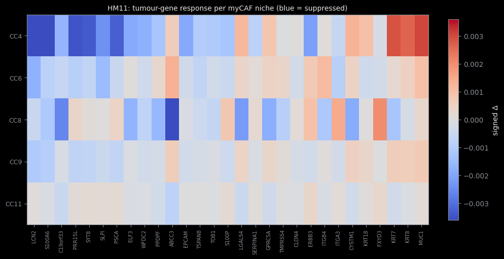

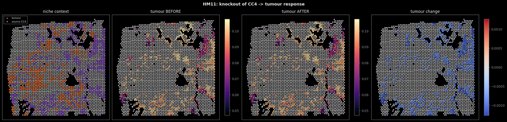

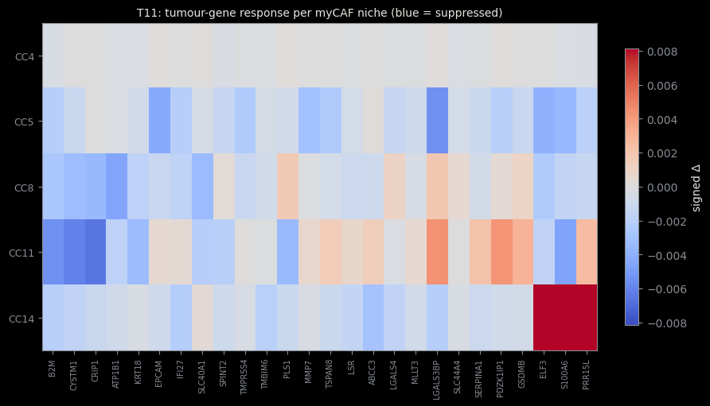

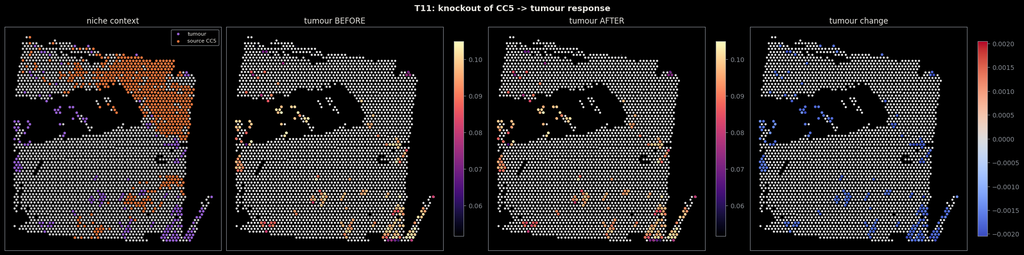

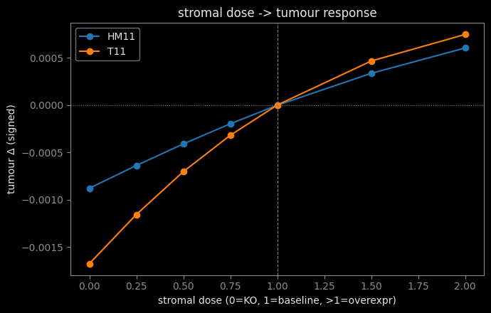

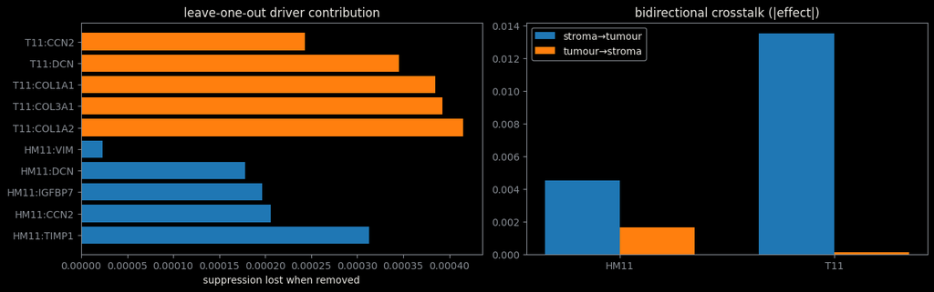

```
saved all figures
```

```python
for nm, st in states.items():
    best,pack,cf_best,resp_df=strongest[nm]
    if resp_df is not None and len(resp_df):
        rd=resp_df[resp_df.mean(0).sort_values().index]
        fig,ax=plt.subplots(figsize=(max(8,rd.shape[1]*0.34),0.6*len(rd)+2),constrained_layout=True)
        lim=np.percentile(np.abs(rd.values),98)+1e-12
        im=ax.imshow(rd.values,cmap="coolwarm",norm=TwoSlopeNorm(0,-lim,lim),aspect="auto")
        ax.set_xticks(range(rd.shape[1])); ax.set_xticklabels(rd.columns,rotation=90,fontsize=7)
        ax.set_yticks(range(len(rd))); ax.set_yticklabels(rd.index,fontsize=9)
        ax.set_title(f"{nm}: tumour-gene response per myCAF niche (blue = decreased)",fontsize=10)
        fig.colorbar(im,ax=ax,fraction=0.025,label="signed Δ"); fig.savefig(f"{OUTDIR}/{nm}_niche_response_heatmap.png",dpi=130,bbox_inches="tight"); plt.show()
    if cf_best is not None:
        coords=st["a"].obsm["spatial"]; cc=st["cc"]; tum=st["tum_spots"]; tg=st["tum_genes"]
        before=st["base"][:,tg].mean(1); after=cf_best[:,tg].mean(1); diff=after-before; src_mask=(cc==best); x,y=coords[:,0],coords[:,1]
        fig,ax=plt.subplots(1,4,figsize=(22,5.4),constrained_layout=True)
        ax[0].scatter(x,y,s=6,c="#cccccc"); ax[0].scatter(x[tum],y[tum],s=9,c="#945ecf",label="tumour")
        ax[0].scatter(x[src_mask],y[src_mask],s=9,c="#e8743b",label=f"source {best}"); ax[0].legend(fontsize=8); ax[0].set_title("niche context")
        vlo,vhi=np.percentile(np.r_[before[tum],after[tum]],[2,98])
        for axi,val,t in [(ax[1],before,"tumour BEFORE"),(ax[2],after,"tumour AFTER")]:
            axi.scatter(x,y,s=5,c="#eee"); s2=axi.scatter(x[tum],y[tum],s=10,c=val[tum],cmap="magma",vmin=vlo,vmax=vhi); axi.set_title(t); fig.colorbar(s2,ax=axi,fraction=0.045)
        lim=np.percentile(np.abs(diff[tum]),98)+1e-12
        s3=ax[3].scatter(x[tum],y[tum],s=10,c=diff[tum],cmap="coolwarm",norm=TwoSlopeNorm(0,-lim,lim)); ax[3].scatter(x[~tum],y[~tum],s=5,c="#eee"); ax[3].set_title("tumour change"); fig.colorbar(s3,ax=ax[3],fraction=0.045)
        for a_ in ax: a_.set_xticks([]); a_.set_yticks([]); a_.set_aspect("equal")
        fig.suptitle(f"{nm}: initial downscaling of {best} -> tumour response",fontsize=13,weight="bold")
        fig.savefig(f"{OUTDIR}/{nm}_tumour_maps.png",dpi=120,bbox_inches="tight"); plt.show()

fig,ax=plt.subplots(figsize=(7,4.5))
for nm in states:
    dd=dose_df[dose_df.section==nm]; ax.plot(dd.dose,dd.tumour_delta,"o-",label=nm)
ax.axhline(0,color="grey",lw=0.8,ls=":"); ax.axvline(1,color="grey",lw=0.8,ls="--")
ax.set_xlabel("stromal dose (0=strong reduction, 1=baseline, >1=increased input)"); ax.set_ylabel("tumour Δ (signed)")
ax.set_title("stromal dose -> tumour response"); ax.legend(); plt.tight_layout(); plt.savefig(f"{OUTDIR}/dose_response.png",dpi=130); plt.show()

fig,ax=plt.subplots(1,2,figsize=(13,4),constrained_layout=True)
for nm in states:
    lo=loo_df[loo_df.section==nm]; ax[0].barh([f"{nm}:{g}" for g in lo.gene], lo.contribution)
ax[0].axvline(0,color="grey",lw=0.6); ax[0].set_title("leave-one-out driver contribution"); ax[0].set_xlabel("decrease score lost when omitted")
bd=pd.DataFrame(bidir_rows); xpos=np.arange(len(bd)); w=0.35
ax[1].bar(xpos-w/2,bd.stroma_to_tumour.abs(),w,label="stroma→tumour"); ax[1].bar(xpos+w/2,bd.tumour_to_stroma.abs(),w,label="tumour→stroma")
ax[1].set_xticks(xpos); ax[1].set_xticklabels(bd.section); ax[1].set_title("reciprocal model-response magnitude"); ax[1].legend()
fig.savefig(f"{OUTDIR}/loo_and_bidirectional.png",dpi=130,bbox_inches="tight"); plt.show()
print("saved all figures")
```

## Part 3. Validation and design checks

This part audits the executed choices and quantifies their limitations. The first analysis evaluates the signed within- and cross-programme blocks in both HM11 and T11. It reports block means, a fitted-matrix negative-tail summary, and a 2,000-draw random-partition test for the cross-block mean.

The eight checks that follow use one section at a time, controlled by `VAL_SECTION`, which is HM11 in the stored execution. They cover the spherical round trip, source-programme registration, cross-block permutation evidence, sensitivity to the retained coupling fraction, synthetic sign recovery, graph- distance behaviour, control integrity, and seed sensitivity. A final cell repeats the cross-block permutation and coupling-retention sweep for both sections.

### 3.1 Signed within- and cross-programme block test

For each section, the fitted sparse coupling is divided into within-fibrotic, within-tumour, and fibrotic-by-tumour blocks. The analysis reports the mean and density of each relevant block. A binomial tail summary describes how many selected coefficients fall in the fitted matrix's negative tail, while the random-partition test asks whether the cross-block mean is more negative than equally sized random gene partitions. The random-partition result is the external statistical comparison used for the compartment-level claim.

```python
# 3.1 signed intra vs inter block test, run on BOTH sections using the stored sparse couplings
from scipy.stats import binomtest
def intra_inter_signed(G, fib, tum, seed=SEED, B=2000):
    G = (np.asarray(G) + np.asarray(G).T) / 2.0
    inter   = G[np.ix_(fib, tum)]
    intra_f = G[np.ix_(fib, fib)][~np.eye(len(fib), dtype=bool)]
    intra_t = G[np.ix_(tum, tum)][~np.eye(len(tum), dtype=bool)]
    off = G[~np.eye(len(G), dtype=bool)]
    p5 = np.percentile(off, 5); flat = inter.ravel()
    nneg = int((flat <= p5).sum())
    binom_p = binomtest(nneg, len(flat), 0.05, alternative="greater").pvalue
    rng = np.random.RandomState(seed); idx = np.arange(len(G)); nf, nt = len(fib), len(tum)
    null = np.empty(B)
    for b in range(B):
        perm = rng.permutation(idx); f2, t2 = perm[:nf], perm[nf:nf+nt]
        null[b] = G[np.ix_(f2, t2)].mean()
    real = float(inter.mean()); perm_p = float((null <= real).mean())
    return dict(intra_fibrotic_mean=float(intra_f.mean()), intra_tumour_mean=float(intra_t.mean()),
                inter_cross_mean=real, inter_density=float((np.abs(inter) > 1e-9).mean()),
                inter_frac_in_neg_tail=nneg/len(flat), binom_p=float(binom_p),
                perm_null_mean=float(null.mean()), perm_p=perm_p)

rows = []
for nm, d in data.items():
    G = d["G2G_sparse"]; fib, tum = d["fib_genes"], d["tum_genes"]
    log_shape(f"coupling W[{nm}] (genes, genes)", np.asarray(G))
    r = intra_inter_signed(G, fib, tum); rows.append(dict(section=nm, **r))
    print(f"[{nm}]  intra fibrotic {r['intra_fibrotic_mean']:+.4f} | intra tumour {r['intra_tumour_mean']:+.4f} | "
          f"INTER cross {r['inter_cross_mean']:+.4f} (density {r['inter_density']:.2f})")
    print(f"       inter in negative tail {r['inter_frac_in_neg_tail']:.2f}  binomial p {r['binom_p']:.1e}  |  "
          f"permutation p {r['perm_p']:.4f} (null mean {r['perm_null_mean']:+.4f})\n")
pd.DataFrame(rows).to_csv(f"{OUTDIR}/signed_intra_vs_inter_both_sections.csv", index=False)
print("saved signed_intra_vs_inter_both_sections.csv")
```

```
shape | coupling W[HM11] (genes, genes) = (117, 117)
[HM11]  intra fibrotic -0.0089 | intra tumour +0.0065 | INTER cross -0.0100 (density 0.67)
       inter in negative tail 0.05  binomial p 3.1e-01  |  permutation p 0.4320 (null mean -0.0077)

shape | coupling W[T11] (genes, genes) = (117, 117)
[T11]  intra fibrotic -0.0077 | intra tumour +0.0098 | INTER cross -0.0058 (density 0.66)
       inter in negative tail 0.05  binomial p 3.8e-01  |  permutation p 0.5150 (null mean -0.0061)

saved signed_intra_vs_inter_both_sections.csv
```

### 3.2 Single-section validation namespace

This cell reconstructs the section-specific objects required by the eight checks. `VAL_SECTION` is set to HM11 in the stored execution and can be changed to T11 for an equivalent primary-section audit. The faithful, signed, and sparse variants are retrained in this separate validation namespace, and each check adds its result to a common summary table.

```python
VAL_SECTION = "HM11"   # set to "T11" and re-run Part 3 to validate the primary section
CHECKS=[]
def block_stats(G,fib,tum):
    off=~np.eye(len(G),dtype=bool); cb=G[np.ix_(fib,tum)]
    return dict(offdiag_density=float((np.abs(G[off])>1e-9).mean()),
                cross_density=float((np.abs(cb)>1e-9).mean()), cross_mean=float(cb.mean()))
nm=VAL_SECTION; d=data[nm]; fib,tum=d['fib_genes'],d['tum_genes']
expr,edges,n=d['expr'],d['edges'],d['n']
models={m:train_mode(get_loader(d['tmp']),n,m) for m in ['faithful','signed','sparse']}
print('trained faithful/signed/sparse (one seed)')
```

```
trained faithful/signed/sparse (one seed)
```

```python
# shape log for the validation namespace
log_shape("expr (spots, genes)", expr)
log_shape("edges (2, n_edges)", edges)
for m in ["faithful", "signed", "sparse"]:
    G = models[m].conv1.lin.weight.detach().cpu().numpy()
    log_shape(f"coupling W[{m}] (genes, genes)", G)
print(f"n_genes={n}  fibrotic={len(fib)}  tumour={len(tum)}")
```

```
shape | expr (spots, genes)            = (3921, 117)
shape | edges (2, n_edges)             = (2, 23526)
shape | coupling W[faithful] (genes, genes) = (117, 117)
shape | coupling W[signed] (genes, genes) = (117, 117)
shape | coupling W[sparse] (genes, genes) = (117, 117)
n_genes=117  fibrotic=26  tumour=29
```

### Check 1. Spherical round-trip fidelity

The expression matrix is transformed to the spherical representation and mapped back. The correlation between the original and reconstructed values quantifies numerical round-trip fidelity for this transformation.

```python
scm=simcomen(input_dim=n,output_dim=n,n_neighbors=K,seed=SEED); scm.to(device)
sx=torch.nan_to_num(scm.calc_sphex(torch.from_numpy(expr).to(device))); gx=scm.calc_gex(sx).detach().cpu().numpy()
rt=np.corrcoef(expr.ravel(),gx.ravel())[0,1]
v='PASS' if rt>0.99 else 'CAVEAT'
print(f'CHOICE: sphere-normalise expression | round-trip corr={rt:.4f} | VERDICT: {v}')
CHECKS.append(dict(check='1 spherical normalization',stat=f'round-trip={rt:.4f}',verdict=v))
```

```
CHOICE: sphere-normalise expression | round-trip corr=0.9985 | VERDICT: PASS
```

### Check 2. Initial programme downscaling registers at the source

The leading fibrotic programme is reduced in the initial state and the model is relaxed. Source-programme expression before and after relaxation is compared to verify that the intended perturbation remains strongly represented, even though the selected genes are not permanently clamped.

```python
mdl=models['sparse']; best,pack,base=strongest_fibrotic(d,mdl); srcr,sub,gidx=pack
cf=relax(mdl,initial_downscale(expr,gidx,srcr),edges,n)
b=base[np.ix_(srcr,gidx)].mean(); a=cf[np.ix_(srcr,gidx)].mean()
v='PASS' if a<b*0.8 else 'FAIL'
print(f'CHECK: initial_downscale()+relax() | source expr {b:.4f} -> {a:.4f} | VERDICT: {v}')
CHECKS.append(dict(check='2 source downscaling registers',stat=f'{b:.4f}->{a:.4f}',verdict=v))
```

```
CHOICE: initial_downscale()+relax() | source expr 0.1262 -> 0.0144 | VERDICT: PASS
```

### Check 3. Cross-block random-partition test

The signed fibrotic-by-tumour mean is compared with a null distribution generated from random gene partitions of the same sizes. A small one-sided p-value would indicate that the selected block is more negative than expected under this null. A non-significant value means that the observed mean is compatible with the random-partition distribution.

```python
for m in ['faithful','signed','sparse']:
    G=models[m].conv1.lin.weight.detach().cpu().numpy(); G=(G+G.T)/2; st=block_stats(G,fib,tum)
    print(f'  {m:9s} cross_density={st["cross_density"]:.3f} cross_mean={st["cross_mean"]:+.4f}')
# permutation: is the signed cross-block mean MORE negative than random gene partitions?
G=models['signed'].conv1.lin.weight.detach().cpu().numpy(); G=(G+G.T)/2
real=float(G[np.ix_(fib,tum)].mean()); rs=np.random.RandomState(SEED); nf,nt=len(fib),len(tum)
null=np.array([G[np.ix_(p[:nf],p[nf:nf+nt])].mean() for p in (rs.permutation(len(G)) for _ in range(2000))])
p=float((null<=real).mean()); z=float((real-null.mean())/(null.std()+1e-12))
faith_cross=block_stats((models['faithful'].conv1.lin.weight.detach().cpu().numpy()),fib,tum)['cross_density']
v='PASS' if (p<0.05 and faith_cross<0.1) else ('CAVEAT' if p<0.1 else 'FAIL')
print(f'\nCHOICE: signed (not faithful) | faithful cross_density={faith_cross:.3f} (empty) | '
      f'signed cross real={real:+.4f} vs null={null.mean():+.4f} z={z:+.2f} perm p={p:.4f} | VERDICT: {v}')
CHECKS.append(dict(check='3 cross-block permutation test',stat=f'perm p={p:.4f}, z={z:+.2f}',verdict=v))
```

```
  faithful  cross_density=0.000 cross_mean=+0.0000
  signed    cross_density=1.000 cross_mean=-0.0144
  sparse    cross_density=0.668 cross_mean=-0.0101

CHOICE: signed (not faithful) | faithful cross_density=0.000 (empty) | signed cross real=-0.0144 vs null=-0.0080 z=-0.53 perm p=0.2990 | VERDICT: FAIL
```

### Reading Check 3. Negative fitted mean, compatible with the null

In the stored HM11 execution, the signed cross-block mean was approximately -0.014, while the random- partition distribution was centred near -0.008, giving a one-sided permutation p-value near 0.30. The observed mean is therefore not statistically distinguished from the matched random partitions. The negative mean can be reported descriptively, but the current test does not establish a compartment- specific negative signal or determine why the comparison was non-significant.

### Check 4. Sensitivity to the retained coupling fraction

The retained fraction is varied and the selected-driver response is compared with size-matched random gene sets. This is a sensitivity analysis: it shows how coupling density changes the nominal driver-versus-random contrast and should not be interpreted as an independent significance test.

```python
import copy
srcr2=np.where(d['fib_spots'])[0]; tumr=np.where(d['tum_spots'])[0]
n_drivers=len(fib); N_RANDOM=6
print(f'n_drivers={n_drivers}  n_random_sets={N_RANDOM} (size-matched)  n_tumour_genes={len(tum)}')
signed_G=models['signed'].conv1.lin.weight.detach().cpu().numpy(); signed_G=(signed_G+signed_G.T)/2
def thr(G,keep):
    off=~np.eye(len(G),dtype=bool); tau=np.quantile(np.abs(G[off]),1-keep)
    Gs=np.where(np.abs(G)>=tau,G,0.0); np.fill_diagonal(Gs,1.0); return Gs
def eff_fn(Gs):
    m=copy.deepcopy(models['signed'])
    with torch.no_grad(): m.conv1.lin.weight.copy_(torch.from_numpy(Gs.astype('float32')).to(m.conv1.lin.weight.device))
    base=relax(m,expr,edges,n)
    return lambda gi,rw: float((relax(m,initial_downscale(expr,gi,rw),edges,n)-base)[np.ix_(tumr,tum)].mean())
rng=np.random.RandomState(SEED); sweep=[]
for keep in [0.15,0.30,0.45,0.65,0.85]:
    e=eff_fn(thr(signed_G,keep)); dD=e(fib,srcr2)
    rD=float(np.mean([e(list(rng.choice(n,size=n_drivers,replace=False)),srcr2) for _ in range(N_RANDOM)]))
    spec=abs(dD)/(abs(rD)+1e-12); sweep.append(dict(keep=keep,driverD=round(dD,6),randomD=round(rD,6),specificity=round(spec,2)))
    print(f'  keep={keep:.2f}: driverD={dD:+.6f} randomD={rD:+.6f} specificity={spec:.2f}x')
bestk=max(sweep,key=lambda r:r['specificity'])
pd.DataFrame(sweep).to_csv(f'{OUTDIR}/design_keep_sweep.csv',index=False)
print(f"\nSENSITIVITY: largest nominal specificity at keep={bestk['keep']} (specificity={bestk['specificity']}x) | "
      f"current 0.65 -> {[s for s in sweep if s['keep']==0.65][0]['specificity']}x")
CHECKS.append(dict(check='4 SPARSE_KEEP choice',stat=f"largest nominal ratio at keep={bestk['keep']} ({bestk['specificity']}x)",
                   verdict='INFO'))
```

```
n_drivers=26  n_random_sets=6 (size-matched)  n_tumour_genes=29
  keep=0.15: driverD=-0.012469 randomD=-0.002796 specificity=4.46x
  keep=0.30: driverD=-0.011652 randomD=-0.000015 specificity=762.59x
  keep=0.45: driverD=-0.014093 randomD=-0.002353 specificity=5.99x
  keep=0.65: driverD=-0.013095 randomD=-0.001776 specificity=7.37x
  keep=0.85: driverD=-0.013394 randomD=-0.001593 specificity=8.41x

SENSITIVITY: largest nominal specificity at keep=0.3 (specificity=762.59x) | current 0.65 -> 7.37x
```

### Reading Check 4. Specificity ratios are not significance tests

The largest nominal ratio occurs near keep = 0.30 because the mean random response is extremely close to zero. This makes the ratio numerically unstable. At keep = 0.65, the nominal specificity is 7.37. These ratios describe a response contrast under a particular fitted model; they do not establish that the compartment-level cross-block is statistically significant.

### Check 5. Synthetic coefficient-sign recovery

A synthetic signed ground truth is generated and refitted. Agreement between planted and recovered coefficient signs is tested against chance, and rank correlation is also reported. This check evaluates sign recovery in the synthetic setting only; it does not establish biological direction or validate every fitted coefficient in HM11 or T11.

```python
import anndata as ad
from celcomen.utils.helpers import get_pos
from scipy.stats import spearmanr, binomtest
def signed_sign_recovery(n_genes=12,n_x=16,n_y=16,gen_steps=250,seed=SEED):
    rng=np.random.RandomState(seed)
    Wt=rng.uniform(-1,1,(n_genes,n_genes)).astype('float32'); Wt=normalize_g2g_signed((Wt+Wt.T)/2)
    Gi=np.eye(n_genes,dtype='float32'); coords=get_pos(n_x,n_y); e=edges_of(coords)
    scm=simcomen(input_dim=n_genes,output_dim=n_genes,n_neighbors=K,seed=seed)
    scm.set_g2g(torch.from_numpy(Wt.copy())); scm.set_g2g_intra(torch.from_numpy(Gi.copy())); scm.to(device)
    scm.set_sphex(torch.from_numpy(rng.uniform(0,np.pi,(coords.shape[0],n_genes-1)).astype('float32')).to(device))
    opt=torch.optim.SGD(scm.parameters(),lr=1e-2)
    for _ in range(gen_steps):
        msg,mi,lz=scm(e.to(device),1)
        loss=-(-lz+ZMFT*torch.trace(torch.mm(msg,scm.gex.t()))+ZMFT*torch.trace(torch.mm(mi,scm.gex.t())))
        loss.backward(); opt.step(); opt.zero_grad()
    gen=np.nan_to_num(scm.gex.detach().cpu().numpy()); nf=np.sqrt((gen**2).sum(1,keepdims=True)); nf[nf==0]=1; gen=(gen/nf).astype('float32')
    A=ad.AnnData(X=csr_matrix(gen)); A.obs[SAMPLE_ID]='0'; A.var_names=[f'g{i}' for i in range(n_genes)]; A.obsm['spatial']=coords
    tmp=tempfile.NamedTemporaryFile(suffix='.h5ad',delete=False).name; A.write(tmp); _TMP.append(tmp)
    mdl=train_mode(get_loader(tmp),n_genes,'signed'); Wr=mdl.conv1.lin.weight.detach().cpu().numpy(); Wr=(Wr+Wr.T)/2
    iu=np.triu_indices(n_genes,1); wt,wr=Wt[iu],Wr[iu]; neg=wt<0
    sa=float((np.sign(wt)==np.sign(wr)).mean()); na=float((np.sign(wt[neg])==np.sign(wr[neg])).mean()) if neg.any() else np.nan
    ncorr=int((np.sign(wt)==np.sign(wr)).sum()); ntot=len(wt); nnegc=int((np.sign(wt[neg])==np.sign(wr[neg])).sum())
    p_all=binomtest(ncorr,ntot,0.5,alternative='greater').pvalue
    p_neg=binomtest(nnegc,int(neg.sum()),0.5,alternative='greater').pvalue if neg.any() else np.nan
    return dict(sign_agreement=sa,negative_sign_agreement=na,spearman=float(spearmanr(wt,wr).correlation),
                n_neg=int(neg.sum()),p_all=p_all,p_neg=p_neg,n_correct=ncorr,n_total=ntot)
sr=signed_sign_recovery(n_genes=12)
v='PASS' if (sr['sign_agreement']>0.7 and sr['p_all']<0.05) else 'CAVEAT'
print(f"SYNTHETIC CHECK: signed extension recovers coefficient signs | sign_agreement={sr['sign_agreement']:.2f} "
      f"(binom p={sr['p_all']:.4f}) | negatives={sr['negative_sign_agreement']:.2f} over {sr['n_neg']} pairs "
      f"(binom p={sr['p_neg']:.4f}) | Spearman={sr['spearman']:+.2f} | VERDICT: {v}")
pd.DataFrame([sr]).to_csv(f'{OUTDIR}/design_sign_recovery.csv',index=False)
CHECKS.append(dict(check='5 sign recovery (binomial)',stat=f"agree={sr['sign_agreement']:.2f} p={sr['p_all']:.4f}, neg={sr['n_neg']}pairs p={sr['p_neg']:.4f}",verdict=v))
```

```
CHOICE: signed extension recovers signs | sign_agreement=0.88 (binom p=0.0000) | negatives=0.91 over 32 pairs (binom p=0.0000) | Spearman=+0.81 | VERDICT: PASS
```

### Check 6. Graph-distance behaviour

The absolute model response is grouped by graph distance from the selected source niche. A short-range spatial response would decline across successive hops. A response that remains approximately flat after the first hop is interpreted as predominantly global or mean-field.

```python
g=kneighbors_graph(d['a'].obsm['spatial'],K,include_self=False); adj=((g+g.T)>0).astype(np.int8).tocsr()
dist=shortest_path(adj,method='D',unweighted=True,indices=srcr).min(0)
nonko=[i for i in range(n) if i not in gidx]; effv=np.abs(cf[:,nonko]-base[:,nonko]).mean(1)
hops=[]
for hop in range(4):
    m=dist==hop
    if m.sum(): hops.append(effv[m].mean()); print(f'  hop {hop}: n={int(m.sum()):4d} mean_effect={effv[m].mean():.6f}')
decays = len(hops)>=3 and hops[2]<hops[1]*0.7
v='SHORT-RANGE DECAY' if decays else 'GLOBAL/MEAN-FIELD'
print(f'\nREADOUT: graph-distance behaviour | effect {"decays" if decays else "stays flat"} past hop 1 | {v}')
CHECKS.append(dict(check='6 propagation locality',stat='flat past hop1' if not decays else 'decays',verdict=v))
```

```
  hop 0: n= 587 mean_effect=0.003925
  hop 1: n=1061 mean_effect=0.001912
  hop 2: n= 728 mean_effect=0.001949
  hop 3: n= 451 mean_effect=0.001960

CHOICE/READOUT: propagation locality | effect stays flat past hop 1 | GLOBAL (report as limitation)
```

### Reading Check 6. The stored response is predominantly global

The mean response fell between the source and the first hop but remained approximately flat across hops 1, 2, and 3. The executed model therefore did not recover a short-range decay pattern. This supports a global or mean-field description of the fitted response. The current analysis does not identify a single cause for the absence of locality.

### Check 7. Control integrity

The shuffled-graph and random-niche controls are audited rather than assumed to be valid. The graph comparison tests dependence on the recorded spatial geometry, while the niche audit checks tumour overlap and source composition before the alternative niches are interpreted as neutral controls.

```python
# needs: states (per-section model + expr + edges + cc + tum_spots + drv), nonfibrotic_niches,
# strongest_fibrotic, relax, knockout, edges_of. This section rebuilds a minimal `states` for HM11
# from the objects already in memory so the diagnostic is self-contained.
st = dict(model=models['sparse'], expr=expr, edges=edges, n=n,
          cc=d['cc'], tum_spots=d['tum_spots'], tum_genes=tum, drv=d['drv'],
          fib_spots=d['fib_spots'])
best,pack,base = strongest_fibrotic(d, st['model']); src_rows,sub,gidx = pack
tumr = np.where(st['tum_spots'])[0]
reference_response = float((relax(st['model'],initial_downscale(expr,gidx,src_rows),edges,n)-base)[np.ix_(tumr,tum)].mean())

# FIX: shuffled_graph with the SAME model (only edges shuffled)
rsh=np.random.RandomState(1000+SEED); coords=d['a'].obsm['spatial'].copy(); rsh.shuffle(coords)
edges_sh=edges_of(coords)
base_sh=relax(st['model'],expr,edges_sh,n)
cf_sh  =relax(st['model'],initial_downscale(expr,gidx,src_rows),edges_sh,n)
shuffled_graph_fixed=float((cf_sh-base_sh)[np.ix_(tumr,tum)].mean())
print(f'shuffled_graph (SAME model, edges shuffled) = {shuffled_graph_fixed:+.6f}  vs reference = {reference_response:+.6f}')
ratio=abs(shuffled_graph_fixed)/(abs(reference_response)+1e-12)
print(f'  -> ratio shuffled/real = {ratio:.2f}  '
      f"({'still ~real => effect NOT spatially dependent (mean-field)' if 0.7<ratio<1.4 else 'differs => geometry matters'})")

#  AUDIT: what are the random_niche controls really?
try:
    nf = nonfibrotic_niches(st)
except Exception:
    # fallback: non-fibrotic = niches whose spots are not (mostly) fibrotic
    all_cc=np.unique(d['cc']); fibset=set(d['cc'][d['fib_spots']])
    nf=[c for c in all_cc if c not in fibset]
print('\nrandom_niche audit (non-fibrotic niches used as controls):')
print(f"  {'niche':>8} {'theme':>16} {'n_spots':>8} {'tumour_overlap':>14} {'flag'}")
rows_audit=[]
fib_n = int(len(src_rows))
for c in list(nf):
    src_c=np.where(d['cc']==c)[0]; n_sp=len(src_c)
    overlap=int(np.intersect1d(src_c, tumr).size)
    try: theme=str(d['drv'][d['drv'].CC==c].theme.iloc[0])
    except Exception: theme='?'
    flag=''
    if overlap>0.3*n_sp: flag+='TUMOUR-CONTAMINATED '
    if n_sp>2*fib_n: flag+='MUCH-LARGER '
    if str(theme).lower() in ('tumour','tumor','tumour/metabolic','tumour_metabolic'): flag+='IS-TUMOUR-NICHE '
    rows_audit.append(dict(niche=c,theme=theme,n_spots=n_sp,tumour_overlap=overlap,flag=flag.strip()))
    print(f'  {str(c):>8} {theme:>16} {n_sp:>8} {overlap:>14}  {flag}')
print(f'\n(fibrotic source niche has n_spots={fib_n})')
import pandas as pd
pd.DataFrame(rows_audit).to_csv(f'{OUTDIR}/random_niche_audit.csv',index=False)
contaminated=[r for r in rows_audit if r['flag']]
verdict7=('CAVEAT: random_niche control is unfair — '+
          ', '.join(sorted({w for r in contaminated for w in r['flag'].split()}))) if contaminated else \
         'random_niche controls look clean (size/tumour-matched)'
print('\nVERDICT:', verdict7)
CHECKS.append(dict(check='7 control battery diagnosis',
                   stat=f'shuffled/reference={ratio:.2f}; contaminated_niches={len(contaminated)}/{len(rows_audit)}',
                   verdict='CAVEAT' if contaminated else 'PASS'))
```

```
shuffled_graph (SAME model, edges shuffled) = -0.000866  vs reference = -0.000879
  -> ratio shuffled/real = 0.99  (still ~real => effect NOT spatially dependent (mean-field))

random_niche audit (non-fibrotic niches used as controls):
     niche            theme  n_spots tumour_overlap flag
      CC10 immunosuppressive       80              0
      CC12 tumour/metabolic      393            393  TUMOUR-CONTAMINATED IS-TUMOUR-NICHE
      CC15 tumour/metabolic      100            100  TUMOUR-CONTAMINATED IS-TUMOUR-NICHE
      CC17 tumour/metabolic      221            221  TUMOUR-CONTAMINATED IS-TUMOUR-NICHE

(fibrotic source niche has n_spots=587)

VERDICT: CAVEAT: random_niche control is unfair — IS-TUMOUR-NICHE, TUMOUR-CONTAMINATED
```

### Reading Check 7. The random-niche comparison is not a neutral control

Four nonfibrotic candidate niches were available in the stored HM11 audit. CC10 was immunosuppressive, whereas CC12, CC15, and CC17 were tumour/metabolic niches with complete tumour overlap. Three of four candidates therefore fail the intended neutral-control role. Separately, the shuffled graph reproduced approximately 99% of the reference response, supporting the conclusion that this fitted response depends little on the original graph geometry.

### Check 8. Seed sensitivity of the signed cross block

The signed coupling is retrained under three seeds. Cross-block means, random-partition p-values, and synthetic sign-recovery summaries are recomputed to distinguish a recurring programme-level sign from statistical and pair-level instability.

```python
ROBUST_SEEDS = [0, 1, 2]
rob=[]
for sd in ROBUST_SEEDS:
    np.random.seed(sd); torch.manual_seed(sd)
    m=train_for_seed(get_loader(d['tmp']), n, sd, mode='signed')
    G=m.conv1.lin.weight.detach().cpu().numpy(); G=(G+G.T)/2
    cross=float(G[np.ix_(fib,tum)].mean())
    rs=np.random.RandomState(sd); nf,nt=len(fib),len(tum)
    null=np.array([G[np.ix_(pp[:nf],pp[nf:nf+nt])].mean() for pp in (rs.permutation(len(G)) for _ in range(1000))])
    pcb=float((null<=cross).mean())
    sr=signed_sign_recovery(n_genes=12, seed=sd)
    rob.append(dict(seed=sd, cross_mean=round(cross,5), cross_perm_p=round(pcb,4),
                    sign_agreement=round(sr['sign_agreement'],2), sign_binom_p=round(sr['p_all'],4),
                    n_neg=sr['n_neg'], neg_agreement=round(sr['negative_sign_agreement'],2)))
    print(f"  seed {sd}: cross_mean={cross:+.5f} (perm p={pcb:.4f}) | "
          f"sign_agreement={sr['sign_agreement']:.2f} (binom p={sr['p_all']:.4f}, {sr['n_neg']} neg pairs)")
robdf=pd.DataFrame(rob); robdf.to_csv(f'{OUTDIR}/robustness_seeds.csv',index=False)
cm=robdf.cross_mean; sa=robdf.sign_agreement
print(f"\nacross {len(ROBUST_SEEDS)} seeds:  cross_mean = {cm.mean():+.5f} ± {cm.std():.5f}  |  "
      f"sign_agreement = {sa.mean():.2f} ± {sa.std():.2f}")
stable = bool((robdf.cross_perm_p<0.05).all() and (robdf.sign_agreement>0.7).all())
cross_neg = bool((robdf.cross_mean<0).all())
v = 'PASS' if (stable and cross_neg) else ('CAVEAT' if cross_neg else 'FAIL')
print('VERDICT:', 'negative mean and statistical evidence stable across seeds' if v=='PASS' else
      ('cross-block mean negative in all runs; significance and pair-level recovery vary' if v=='CAVEAT' else 'mean sign not stable'))
CHECKS.append(dict(check='8 robustness across seeds',
                   stat=f'cross={cm.mean():+.5f}±{cm.std():.5f}, sign_agree={sa.mean():.2f}±{sa.std():.2f}',
                   verdict=v))
```

```
  seed 0: cross_mean=-0.01439 (perm p=0.2920) | sign_agreement=0.88 (binom p=0.0000, 32 neg pairs)
```

```
  seed 1: cross_mean=-0.01097 (perm p=0.3930) | sign_agreement=0.48 (binom p=0.6439, 36 neg pairs)
```

```
  seed 2: cross_mean=-0.02254 (perm p=0.0970) | sign_agreement=0.62 (binom p=0.0320, 36 neg pairs)

across 3 seeds:  cross_mean = -0.01597 ± 0.00594  |  sign_agreement = 0.66 ± 0.20
VERDICT: cross-block mean negative in all runs; significance and pair-level recovery vary
```

### Reading Check 8. Recurring negative mean with unstable evidence

The cross-block mean was negative in all three stored HM11 runs (-0.01439, -0.01097, and -0.02254), but none of the corresponding random-partition tests reached 0.05. Synthetic pair-level sign agreement varied from 0.48 to 0.88. The programme-level mean therefore retained a negative descriptive sign in these runs, whereas statistical significance and pair-level recovery remained seed-sensitive. This is not evidence of a stable causal direction.

### Design-check summary

The numerical results and verdicts from the eight checks are collected in one table and exported for audit. “Pass” refers only to the scope of the named implementation or synthetic check; it is not a general validation of biological causality.

```python
summ=pd.DataFrame(CHECKS)
summ.to_csv(f'{OUTDIR}/design_checks_summary.csv',index=False)
print(summ.to_string(index=False))
print('\nsaved design_checks_summary.csv (+ per-check CSVs)')
```

[output not shown]

### 3.9 Cross-block permutation and retention sensitivity in both sections

The final analysis repeats the random-partition test for the signed cross-block mean and reports how the nonzero cross-block mean changes across retained coupling fractions in HM11 and T11. The permutation p-value determines whether the observed section-specific block is unusually negative relative to matched random partitions.

```
[HM11] cross-block real=-0.01437  null=-0.00793  z=-0.53  perm p=0.2990  -> compatible with random-partition null
```

```
[T11] cross-block real=-0.00528  null=-0.00638  z=+0.20  perm p=0.5770  -> compatible with random-partition null
```

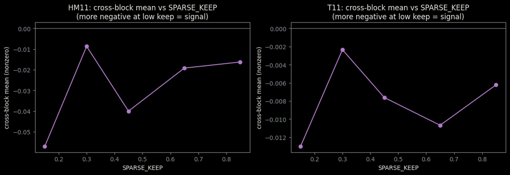

```
saved signed_signal_permutation.csv, signed_signal_sweep.csv, signed_signal_check.png
```

```python
# CROSS-BLOCK CHECK - comparison with matched random gene partitions
# Needs (already in your notebook): data, train_mode, get_loader, OUTDIR, np, pd, plt
# One seed. (1) permutation null + (2) SPARSE_KEEP sweep, per section.

import numpy as np, pandas as pd, matplotlib.pyplot as plt

def _cross_mean(G, fib, tum):
    return float(G[np.ix_(fib, tum)].mean())

def _perm_test(G, fib, tum, n_perm=2000, seed=0):
    rs = np.random.RandomState(seed); n = len(G)
    real = _cross_mean(G, fib, tum); nf, nt = len(fib), len(tum)
    null = np.empty(n_perm)
    for k in range(n_perm):
        perm = rs.permutation(n)
        null[k] = G[np.ix_(perm[:nf], perm[nf:nf+nt])].mean()
    p = float((null <= real).mean())                 # one-sided: more negative than chance
    z = float((real - null.mean()) / (null.std() + 1e-12))
    return real, float(null.mean()), z, p

KEEPS = [0.15, 0.30, 0.45, 0.65, 0.85]
rows, sweep_rows = [], []
fig, axes = plt.subplots(1, len(data), figsize=(6*len(data), 4.2), squeeze=False)

for ax, (nm, d) in zip(axes[0], data.items()):
    fib, tum = d["fib_genes"], d["tum_genes"]
    mdl = train_mode(get_loader(d["tmp"]), d["n"], "signed")          # signed coupling, one seed
    G = mdl.conv1.lin.weight.detach().cpu().numpy(); G = (G + G.T) / 2

    real, nullm, z, p = _perm_test(G, fib, tum, seed=SEED if "SEED" in globals() else 0)
    rows.append(dict(section=nm, cross_mean_real=round(real, 5), null_mean=round(nullm, 5),
                     z=round(z, 2), perm_p=p, verdict="unusually_negative" if p < 0.05 else "compatible_with_null"))
    print(f"[{nm}] cross-block real={real:+.5f}  null={nullm:+.5f}  z={z:+.2f}  "
          f"perm p={p:.4f}  -> {'unusually negative relative to null' if p<0.05 else 'compatible with random-partition null'}")

    off = ~np.eye(len(G), dtype=bool); means = []
    for keep in KEEPS:
        tau = np.quantile(np.abs(G[off]), 1 - keep)
        Gs = np.where(np.abs(G) >= tau, G, 0.0)
        cb = Gs[np.ix_(fib, tum)]; nz = cb != 0
        m = float(cb[nz].mean()) if nz.any() else 0.0
        means.append(m)
        sweep_rows.append(dict(section=nm, keep=keep, cross_density=round(float(nz.mean()), 3),
                               cross_mean_nonzero=round(m, 5)))
    ax.plot(KEEPS, means, "o-", color="#B07BC7"); ax.axhline(0, color="#888", lw=.8)
    ax.set_title(f"{nm}: cross-block mean vs SPARSE_KEEP\n(descriptive sensitivity analysis)")
    ax.set_xlabel("SPARSE_KEEP"); ax.set_ylabel("cross-block mean (nonzero)")

plt.tight_layout(); plt.savefig(f"{OUTDIR}/signed_signal_check.png", dpi=140); plt.show()
pd.DataFrame(rows).to_csv(f"{OUTDIR}/signed_signal_permutation.csv", index=False)
pd.DataFrame(sweep_rows).to_csv(f"{OUTDIR}/signed_signal_sweep.csv", index=False)
print("\nsaved signed_signal_permutation.csv, signed_signal_sweep.csv, signed_signal_check.png")
```

## Final interpretation

The executed analyses show a consistent fitted-model response in which reducing selected fibrotic programmes lowers the tumour-programme readout and increasing their dose raises it. The response sign is repeated across the tested model seeds, while the leading niche and fine-grained coefficient pattern are not fully stable. The reciprocal analysis shows model-response asymmetry, not causal direction, and the combined-niche results are retained as exploratory operational non-additivity.

The validation also identifies clear limits. The signed fibrotic-by-tumour cross-block mean does not exceed the matched random-partition null in HM11 or T11. The response is predominantly global rather than local, graph shuffling preserves nearly all of the HM11 response, and the available random-niche comparison is not a valid neutral control. Synthetic sign recovery supports the implementation in a controlled setting but does not validate individual biological coefficients.

The notebook therefore supports programme and driver prioritisation within a locked fitted model. It does not establish a directed biological causal effect, a statistically distinguished compartment-level signed block, local spatial propagation, or experimentally validated niche interactions. Independent patients, higher-resolution measurements such as single-cell or subcellular spatial platforms, clean controls, and direct perturbation experiments are required for stronger biological conclusions.